# exploratory_personality_with_MI

2023-03-29

# Data Import & Cleaning

## Import data

```r
raw_psych_hum_subj <- import("data/raw/raw_psych_hum_subj.csv")
raw_mktg_hum_subj <- import("data/raw/raw_mktg_hum_subj.csv")
raw_gen_uo_pop <- import("data/raw/raw_gen_uo_pop.csv")
pre_fall22 <- import("data/prescreen/dittersdorf_matches_f22.csv")
pre_winter23 <- import("data/prescreen/dittersdorf_matches_w23.csv")
pre_spring23 <- import("data/prescreen/dittersdorf_matches_s23.csv")
participant_list <- import("data/prescreen/dittersdorf_participants.csv")
```

Fix age before converting variable types

```r
table(raw_psych_hum_subj$Age) # 18 years old = 18
```

```
##
##                        18 18 years old           19           20           21
##          117          220            1          297          120           76
##           22           23           24           25           27           28
##           41            4            3            2            1            1
##           29           30           31           32           33           50
##            1            1            1            1            1            1
```

```r
table(raw_mktg_hum_subj$Age) # 1999 = 24
```

```
##
##        18   19 1999   20   21   22   23   24   25   28 test
##   11    4   13    1   50  119   66    7    9    3    1    3
```

```r
table(raw_gen_uo_pop$Age)
```

```
##
## 18 20 21 22 28
##  2  1  2  1  1
```

```r
raw_psych_hum_subj$Age[raw_psych_hum_subj$Age == "18 years old"] <- 18
raw_mktg_hum_subj$Age[raw_mktg_hum_subj$Age == 1999] <- 24

table(raw_psych_hum_subj$Age) # 18 years old = 18
```

```
##
##      18  19  20  21  22  23  24  25  27  28  29  30  31  32  33  50
## 117 221 297 120  76  41   4   3   2   1   1   1   1   1   1   1   1
```

```r
table(raw_mktg_hum_subj$Age) # 1999 = 24
```

```
##
##        18   19   20   21   22   23   24   25   28 test
##   11    4   13   50  119   66    7   10    3    1    3
```

## Combine dataframes

```r
raw_psych_hum_subj <- raw_psych_hum_subj %>%
  mutate(Age = as.integer(Age),
         Gender = as.factor(Gender),
         framing_condition_DO = as.factor(framing_condition_DO),
         norm_condition_DO = as.factor(norm_condition_DO),
         consumer_behaviors = as.factor(consumer_behaviors),
         skepticism = as.factor(skepticism),
         id = as.factor(id),
         source = strrep("psych_hsp", times = 1))

raw_mktg_hum_subj <- raw_mktg_hum_subj %>%
  mutate(Age = as.integer(Age),
         Gender = as.factor(Gender),
         Gender_5_TEXT = as.character(Gender_5_TEXT),
         Class_Lvl_7_TEXT = as.character(Class_Lvl_7_TEXT),
         Pol_Ornt_8_TEXT = as.character(Pol_Ornt_8_TEXT),
         Ethnicity_8_TEXT = as.character(Ethnicity_8_TEXT),
         skept_open = as.character(skept_open),
         skepticism = as.factor(skepticism),
         id = as.factor(id),
         framing_condition_DO = as.factor(framing_condition_DO),
         norm_condition_DO = as.factor(norm_condition_DO),
         consumer_behaviors = as.factor(consumer_behaviors),
         source = strrep("mktg_hsp", times = 1))

raw_gen_uo_pop <- raw_gen_uo_pop %>%
  mutate(Gender = as.factor(Gender),
         Gender_5_TEXT = as.character(Gender_5_TEXT),
         Class_Lvl_7_TEXT = as.character(Class_Lvl_7_TEXT),
         Pol_Ornt_8_TEXT = as.character(Pol_Ornt_8_TEXT),
         skept_open = as.character(skept_open),
         skepticism = as.factor(skepticism),
         id = as.factor(id),
         framing_condition_DO = as.factor(framing_condition_DO),
         norm_condition_DO = as.factor(norm_condition_DO),
         consumer_behaviors = as.factor(consumer_behaviors),
         source = strrep("gen_UO", times = 1))
```

Specify unique variables to combine prescreen data sets

```r
# Create unique full_name variable
pre_fall22$full_name <- paste(pre_fall22$first_name, pre_fall22$last_name, sep="_")

pre_winter23$full_name <- paste(pre_winter23$first_name, pre_winter23$last_name, sep="_")

pre_spring23$full_name <- paste(pre_spring23$first_name, pre_spring23$last_name, sep="_")

participant_list$full_name <- paste(participant_list$first_name, participant_list$last_name, sep="_")

# Create column indicating which data set rows came from

pre_fall22 <- pre_fall22 %>%
  mutate(term = "fall22")

pre_winter23 <- pre_winter23 %>%
  mutate(term = "winter23")

pre_spring23 <- pre_spring23 %>%
  mutate(term = "spring23")
```

Combine prescreen data

```r
combine1 <- smartbind(pre_fall22, pre_winter23)
combined_prescreen <- smartbind(combine1, pre_spring23)

# nrow(pre_fall22) + nrow(pre_winter23) + nrow(pre_spring23) # n = 1167

combined_prescreen_unique <- combined_prescreen[!duplicated(combined_prescreen$full_name), ] # keeps first row (fall22)
```

Subset key variables

```r
combined_prescreen_key <- combined_prescreen_unique %>%
  dplyr::select(full_name, term, respecting:gratification, honest:gossip)

participant_list_key <- participant_list %>%
  dplyr::select(full_name, survey_id)
```

Merge with participant list

```r
merged_prescreen <- merge(combined_prescreen_key, participant_list_key, by = "full_name")
```

Rename SDR items to match

Convert variable types

```r
merged_prescreen <- merged_prescreen %>%
  mutate(respecting = as.integer(respecting),
         unity = as.integer(unity),
         protecting = as.integer(protecting),
         preventing = as.integer(preventing),
         equality = as.integer(equality),
         peace = as.integer(peace),
         justice = as.integer(justice),
         helpful = as.integer(helpful),
         power = as.integer(power),
         wealth = as.integer(wealth),
         authority = as.integer(authority),
         influential = as.integer(influential),
         ambition = as.integer(ambition),
         pleasures = as.integer(pleasures),
         enjoying = as.integer(enjoying),
         gratification = as.integer(gratification),
         honest = as.integer(honest),
         like = as.integer(like),
         disturbing = as.integer(disturbing),
         regret = as.integer(regret),
         lose_out = as.integer(lose_out),
         rational = as.integer(rational),
         confident = as.integer(confident),
         lover = as.integer(lover),
         lies = as.integer(lies),
         cover_up = as.integer(cover_up),
         advantage = as.integer(advantage),
         get_even = as.integer(get_even),
         behind_back = as.integer(behind_back),
         private_talk = as.integer(private_talk),
         take_things = as.integer(take_things),
         gossip = as.integer(gossip),
         id = as.factor(id))
```

Rename values & socially desirable items in prescreen data to match names in main data:

Combine all data

- First, combine Psych Hum Subj data with Prescreen data based on `id`
- Second, add Mktg Hum Subj data
- Third, add gen UO Pop data

```r
combine1 <- merge(raw_psych_hum_subj, merged_prescreen, by = "id")
combine2 <- smartbind(combine1, raw_mktg_hum_subj)
combine3 <- smartbind(combine2, raw_gen_uo_pop)
```

## Remove duplicate cases

Identify duplicate cases

```r
# first, add unique row #s
combine3 <- combine3 %>%
  mutate(row = 1:nrow(combine3))

combine3[duplicated(combine3$id),] # Only rows 1 through 858 have unique id #s

# write.csv(combine3, "combined_data.csv")
```

Row IDs to remove:

- 13 (participant’s second time completing study)
- 134 (participant didn’t complete study first time)
- 145 (participant didn’t complete study first time)
- 308 (participant’s second time completing study)
- 672 (participant’s second time completing study)
- 743 (participant didn’t complete study first time)
- 790 (participant didn’t complete study first time)
- 800 (participant didn’t complete study first time)

Remove duplicate rows after resolving:

```r
combine3 <- combine3 %>%
  filter(!row %in% c(13, 134, 145, 308, 672, 743, 790, 800))
```

## Remove rows of all NAs

Identify completely missing rows:

```r
key_vars <- combine3 %>%
  dplyr::select(row, big_2_1:big_2_65, consumer_intentions_1:consumer_intentions_9, consumer_behaviors, clothing_interest_1:clothing_interest_20, ingroup_ident_1:ingroup_ident_14, values_1:values_16, socially_desirable_1:socially_desirable_16, source)

ncol(key_vars) # number of columns - the row # & source column = 141

all_NA_rows <- key_vars[rowSums(is.na(key_vars)) == 141,] # identify rows with 141 NAs (all missing values), row numbers are preserved

all_NA_rows
```

Removing rows of fully missing data

```r
data <- combine3 %>%
  dplyr::filter(!row %in% c(859, 860, 900, 926, 927, 941, 1139, 1141, 1142, 1143, 1144, 1146, 1149, 1150, 1152)) %>% # remove rows containing all NAs
  dplyr::select(-StartDate, -EndDate, -Status, -Progress, -"Duration (in seconds)", -Finished, -RecordedDate, -ResponseId, -DistributionChannel, -UserLanguage, -big_2_DO, -consumer_intentions_DO, -consumer_behaviors_DO, -clothing_interest_DO, -ingroup_ident_DO, -full_name, -code, -socially_desirable_DO, -values_DO, -email_giftcard, -term) # removing variables not in analysis
```

## Number per source

```r
table(data$source)
```

```
##
##    gen_UO  mktg_hsp psych_hsp
##         7       276       850
```

- 850 = psych human subjects pool
- 276 = mktg human subjects pool
- 7 = general UO pop

Rename variables

```r
data <- data %>%
  rename("framing_condition" = "framing_condition_DO",
         "norm_condition" = "norm_condition_DO")
```

Drop unused levels

## Inspect final data

```r
str(data, list.len = ncol(data))

# write.csv(data, "final_data.csv")
```

# Aggregate Variables

## Personality

### Reverse-code

```r
data_R <- data %>%
  mutate(across(c(big_2_11,
                  big_2_16,
                  big_2_26,
                  big_2_31,
                  big_2_36,
                  big_2_51,
                  big_2_12,
                  big_2_17,
                  big_2_22,
                  big_2_37,
                  big_2_42,
                  big_2_47,
                  big_2_3,
                  big_2_8,
                  big_2_23,
                  big_2_28,
                  big_2_48,
                  big_2_58,
                  big_2_4,
                  big_2_9,
                  big_2_24,
                  big_2_29,
                  big_2_44,
                  big_2_49,
                  big_2_5,
                  big_2_25,
                  big_2_30,
                  big_2_45,
                  big_2_50,
                  big_2_55,
                  big_2_63), ~6 - .)) # replace '6' with the max possible value plus 1 for any particular scale
```

### Average items

```r
data_R$extraversion <- data_R %>%
  dplyr::select(big_2_1, big_2_6, big_2_11, big_2_16, big_2_21, big_2_26, big_2_31, big_2_36, big_2_41, big_2_46, big_2_51, big_2_56) %>%
  rowMeans(na.rm = TRUE)


data_R$conscientiousness <- data_R %>%
  dplyr::select(big_2_3, big_2_8, big_2_13, big_2_18, big_2_23, big_2_28, big_2_33, big_2_38, big_2_43, big_2_48, big_2_53, big_2_58) %>%
  rowMeans(na.rm = TRUE)


data_R$agreeableness <- data_R %>%
  dplyr::select(big_2_2, big_2_7, big_2_12, big_2_17, big_2_22, big_2_27, big_2_32, big_2_37, big_2_42, big_2_47, big_2_52, big_2_57) %>%
  rowMeans(na.rm = TRUE)


data_R$neuroticism <- data_R %>%
  dplyr::select(big_2_4, big_2_9, big_2_14, big_2_19, big_2_24, big_2_29, big_2_34, big_2_39, big_2_44, big_2_49, big_2_54, big_2_59) %>%
  rowMeans(na.rm = TRUE)


data_R$openness <- data_R %>%
  dplyr::select(big_2_5, big_2_10, big_2_15, big_2_20, big_2_25, big_2_30, big_2_35, big_2_40, big_2_45, big_2_50, big_2_55, big_2_60) %>%
  rowMeans(na.rm = TRUE)


data_R$honesty <- data_R %>%
  dplyr::select(big_2_61, big_2_62, big_2_63, big_2_64, big_2_65) %>%
  rowMeans(na.rm = TRUE)
```

### Visually inspect

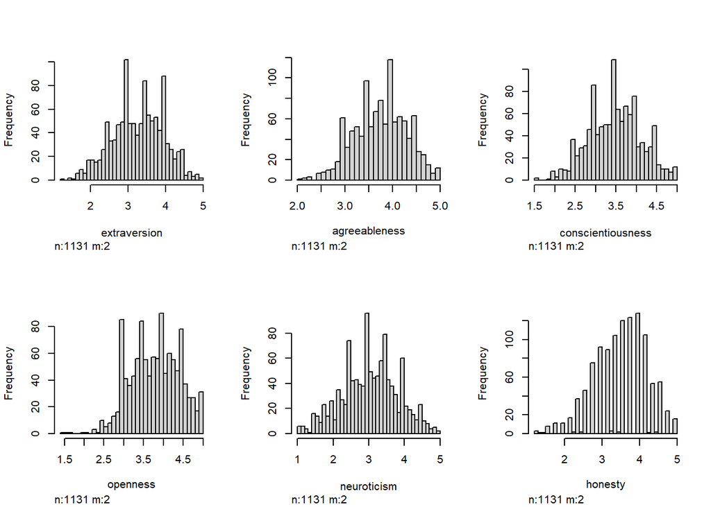

```r
data_R %>%
  dplyr::select(extraversion, agreeableness, conscientiousness, openness, neuroticism, honesty) %>%
  hist()
```

## Clothing Interest

### Reverse-code

```r
data_R <- data_R %>%
  mutate(across(c(clothing_interest_3,
                  clothing_interest_5,
                  clothing_interest_7,
                  clothing_interest_9,
                  clothing_interest_12,
                  clothing_interest_14,
                  clothing_interest_15,
                  clothing_interest_16,
                  clothing_interest_18,
                  clothing_interest_20), ~6 - .)) # replace '#' with the max possible value plus 1 for any particular scale
```

### Average items

```r
data_R$clothing_interest <- data_R %>%
  dplyr::select(clothing_interest_1:clothing_interest_20) %>%
  rowMeans(na.rm = TRUE)
```

### Visually Inspect

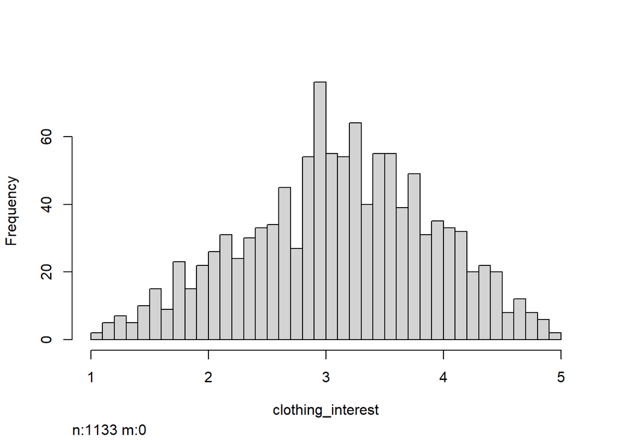

```r
data_R %>%
  dplyr::select(clothing_interest) %>%
  hist()
```

## In-group Identification

### Reverse-code

No items need to be reverse-coded.

### Average items

```r
data_R$ingroup_identification <- data_R %>%
  dplyr::select(ingroup_ident_1:ingroup_ident_14) %>%
  rowMeans(na.rm = TRUE)
```

### Visually Inspect

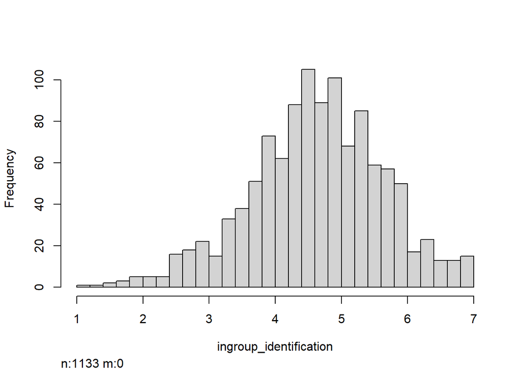

```r
data_R %>%
  dplyr::select(ingroup_identification) %>%
  hist()
```

## Values

### Reverse-code

No items need to be reverse-coded.

### Recoding scale options

Recoding values:

- -3 = 1
- -2 = 2
- -1 = 3
- 0 = 4
- +1 = 5
- +2 = 6
- +3 = 7

```r
table(data_R$values_1)
```

```
##
##  -3  -2  -1   0   1   2   3
##   5  10  17  40 176 362 508
```

```r
data_R$values_1_rec <- recode(data_R$values_1, `-3` = 1, `-2` = 2, `-1` = 3, `0` = 4, `1` = 5, `2` = 6, `3` = 7)

table(data_R$values_1_rec)
```

```
##
##   1   2   3   4   5   6   7
##   5  10  17  40 176 362 508
```

```r
data_R$values_2_rec <- recode(data_R$values_2, `-3` = 1, `-2` = 2, `-1` = 3, `0` = 4, `1` = 5, `2` = 6, `3` = 7)
data_R$values_3_rec <- recode(data_R$values_3, `-3` = 1, `-2` = 2, `-1` = 3, `0` = 4, `1` = 5, `2` = 6, `3` = 7)
data_R$values_4_rec <- recode(data_R$values_4, `-3` = 1, `-2` = 2, `-1` = 3, `0` = 4, `1` = 5, `2` = 6, `3` = 7)
data_R$values_5_rec <- recode(data_R$values_5, `-3` = 1, `-2` = 2, `-1` = 3, `0` = 4, `1` = 5, `2` = 6, `3` = 7)
data_R$values_6_rec <- recode(data_R$values_6, `-3` = 1, `-2` = 2, `-1` = 3, `0` = 4, `1` = 5, `2` = 6, `3` = 7)
data_R$values_7_rec <- recode(data_R$values_7, `-3` = 1, `-2` = 2, `-1` = 3, `0` = 4, `1` = 5, `2` = 6, `3` = 7)
data_R$values_8_rec <- recode(data_R$values_8, `-3` = 1, `-2` = 2, `-1` = 3, `0` = 4, `1` = 5, `2` = 6, `3` = 7)
data_R$values_9_rec <- recode(data_R$values_9, `-3` = 1, `-2` = 2, `-1` = 3, `0` = 4, `1` = 5, `2` = 6, `3` = 7)
data_R$values_10_rec <- recode(data_R$values_10, `-3` = 1, `-2` = 2, `-1` = 3, `0` = 4, `1` = 5, `2` = 6, `3` = 7)
data_R$values_11_rec <- recode(data_R$values_11, `-3` = 1, `-2` = 2, `-1` = 3, `0` = 4, `1` = 5, `2` = 6, `3` = 7)
data_R$values_12_rec <- recode(data_R$values_12, `-3` = 1, `-2` = 2, `-1` = 3, `0` = 4, `1` = 5, `2` = 6, `3` = 7)
data_R$values_13_rec <- recode(data_R$values_13, `-3` = 1, `-2` = 2, `-1` = 3, `0` = 4, `1` = 5, `2` = 6, `3` = 7)
data_R$values_14_rec <- recode(data_R$values_14, `-3` = 1, `-2` = 2, `-1` = 3, `0` = 4, `1` = 5, `2` = 6, `3` = 7)
data_R$values_15_rec <- recode(data_R$values_15, `-3` = 1, `-2` = 2, `-1` = 3, `0` = 4, `1` = 5, `2` = 6, `3` = 7)
data_R$values_16_rec <- recode(data_R$values_16, `-3` = 1, `-2` = 2, `-1` = 3, `0` = 4, `1` = 5, `2` = 6, `3` = 7)

table(data_R$values_16)
```

```
##
##  -3  -2  -1   0   1   2   3
##   4  11  29 116 250 394 312
```

```r
table(data_R$values_16_rec)
```

```
##
##   1   2   3   4   5   6   7
##   4  11  29 116 250 394 312
```

### Average items

```r
data_R$biospheric <- data_R %>%
  dplyr::select(values_1_rec:values_4_rec) %>%
  rowMeans(na.rm = TRUE)

data_R$altruistic <- data_R %>%
  dplyr::select(values_5_rec:values_8_rec) %>%
  rowMeans(na.rm = TRUE)

data_R$egoistic <- data_R %>%
  dplyr::select(values_9_rec:values_13_rec) %>%
  rowMeans(na.rm = TRUE)

data_R$hedonic <- data_R %>%
  dplyr::select(values_14_rec:values_16_rec) %>%
  rowMeans(na.rm = TRUE)
```

### Visually inspect

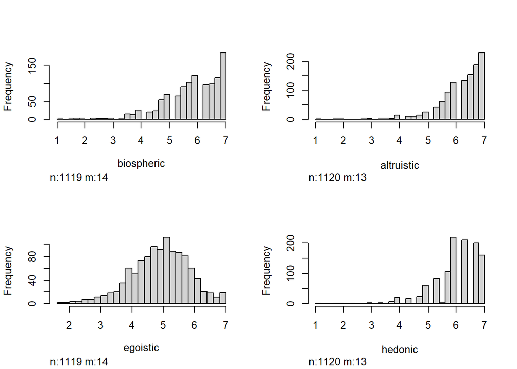

```r
values_df <- data_R %>%
  dplyr::select(biospheric, altruistic, egoistic, hedonic)

values_df %>%
  hist()
```

### Frequency tables

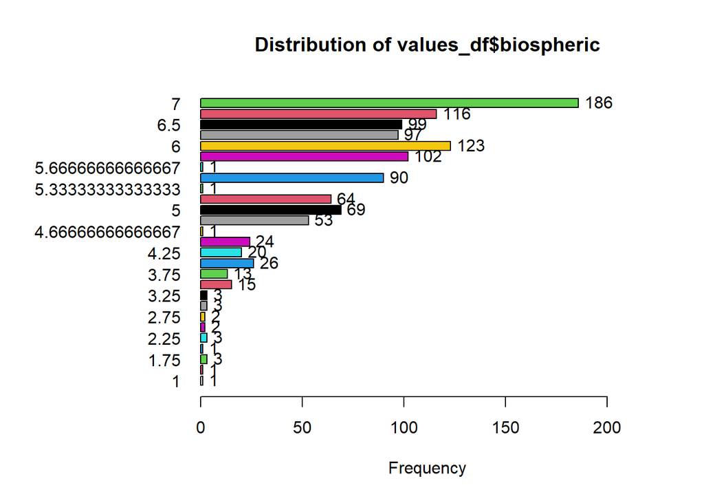

```
## values_df$biospheric :
##                  Frequency   %(NA+) cum.%(NA+)   %(NA-) cum.%(NA-)
## 1                        1      0.1        0.1      0.1        0.1
## 1.5                      1      0.1        0.2      0.1        0.2
## 1.75                     3      0.3        0.4      0.3        0.4
## 2                        1      0.1        0.5      0.1        0.5
## 2.25                     3      0.3        0.8      0.3        0.8
## 2.5                      2      0.2        1.0      0.2        1.0
## 2.75                     2      0.2        1.1      0.2        1.2
## 3                        3      0.3        1.4      0.3        1.4
## 3.25                     3      0.3        1.7      0.3        1.7
## 3.5                     15      1.3        3.0      1.3        3.0
## 3.75                    13      1.1        4.1      1.2        4.2
## 4                       26      2.3        6.4      2.3        6.5
## 4.25                    20      1.8        8.2      1.8        8.3
## 4.5                     24      2.1       10.3      2.1       10.5
## 4.66666666666667         1      0.1       10.4      0.1       10.5
## 4.75                    53      4.7       15.1      4.7       15.3
## 5                       69      6.1       21.2      6.2       21.4
## 5.25                    64      5.6       26.8      5.7       27.2
## 5.33333333333333         1      0.1       26.9      0.1       27.3
## 5.5                     90      7.9       34.9      8.0       35.3
## 5.66666666666667         1      0.1       35.0      0.1       35.4
## 5.75                   102      9.0       44.0      9.1       44.5
## 6                      123     10.9       54.8     11.0       55.5
## 6.25                    97      8.6       63.4      8.7       64.2
## 6.5                     99      8.7       72.1      8.8       73.0
## 6.75                   116     10.2       82.3     10.4       83.4
## 7                      186     16.4       98.8     16.6      100.0
## NaN                     14      1.2      100.0      0.0      100.0
##   Total               1133    100.0      100.0    100.0      100.0
```

```r
# Biospheric values
tab1(values_df$biospheric, sort.group = "descending", cum.percent = TRUE, missing = FALSE, horiz = TRUE)
```

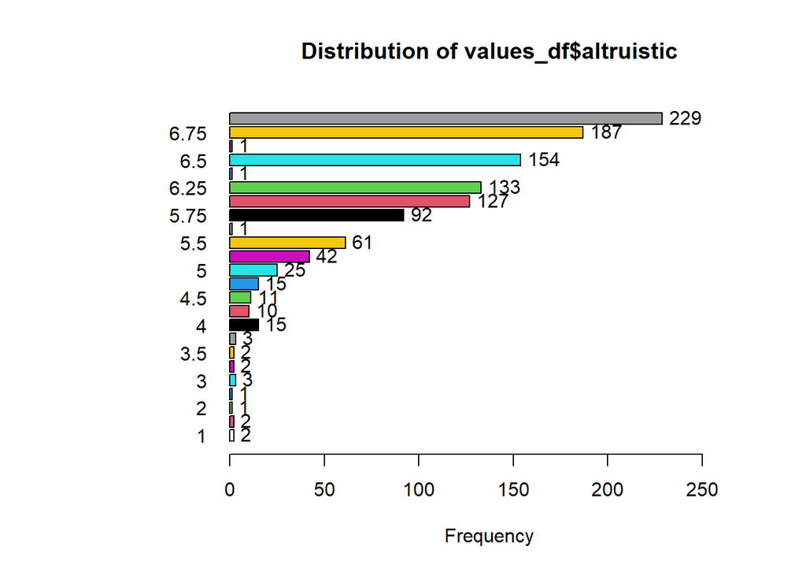

```
## values_df$altruistic :
##                  Frequency   %(NA+) cum.%(NA+)   %(NA-) cum.%(NA-)
## 1                        2      0.2        0.2      0.2        0.2
## 1.75                     2      0.2        0.4      0.2        0.4
## 2                        1      0.1        0.4      0.1        0.4
## 2.75                     1      0.1        0.5      0.1        0.5
## 3                        3      0.3        0.8      0.3        0.8
## 3.25                     2      0.2        1.0      0.2        1.0
## 3.5                      2      0.2        1.1      0.2        1.2
## 3.75                     3      0.3        1.4      0.3        1.4
## 4                       15      1.3        2.7      1.3        2.8
## 4.25                    10      0.9        3.6      0.9        3.7
## 4.5                     11      1.0        4.6      1.0        4.6
## 4.75                    15      1.3        5.9      1.3        6.0
## 5                       25      2.2        8.1      2.2        8.2
## 5.25                    42      3.7       11.8      3.8       12.0
## 5.5                     61      5.4       17.2      5.4       17.4
## 5.66666666666667         1      0.1       17.3      0.1       17.5
## 5.75                    92      8.1       25.4      8.2       25.7
## 6                      127     11.2       36.6     11.3       37.1
## 6.25                   133     11.7       48.4     11.9       48.9
## 6.33333333333333         1      0.1       48.5      0.1       49.0
## 6.5                    154     13.6       62.0     13.8       62.8
## 6.66666666666667         1      0.1       62.1      0.1       62.9
## 6.75                   187     16.5       78.6     16.7       79.6
## 7                      229     20.2       98.9     20.4      100.0
## NaN                     13      1.1      100.0      0.0      100.0
##   Total               1133    100.0      100.0    100.0      100.0
```

```r
# Altruistic values
tab1(values_df$altruistic, sort.group = "descending", cum.percent = TRUE, missing = FALSE, horiz = TRUE)
```

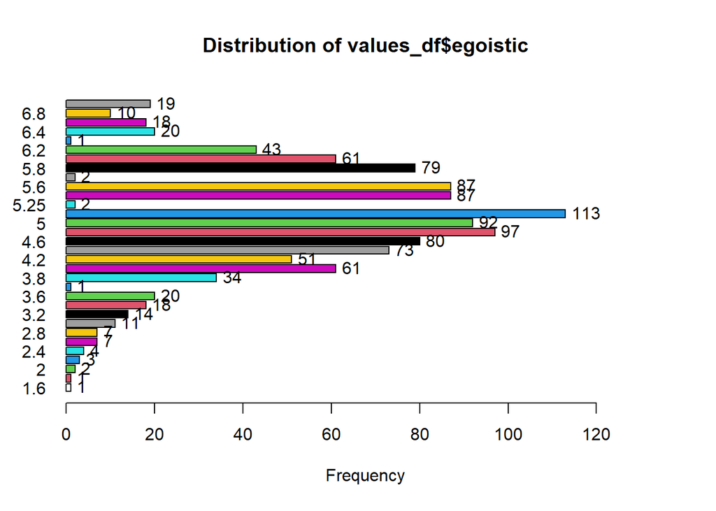

```
## values_df$egoistic :
##         Frequency   %(NA+) cum.%(NA+)   %(NA-) cum.%(NA-)
## 1.6             1      0.1        0.1      0.1        0.1
## 1.8             1      0.1        0.2      0.1        0.2
## 2               2      0.2        0.4      0.2        0.4
## 2.2             3      0.3        0.6      0.3        0.6
## 2.4             4      0.4        1.0      0.4        1.0
## 2.6             7      0.6        1.6      0.6        1.6
## 2.8             7      0.6        2.2      0.6        2.2
## 3              11      1.0        3.2      1.0        3.2
## 3.2            14      1.2        4.4      1.3        4.5
## 3.4            18      1.6        6.0      1.6        6.1
## 3.6            20      1.8        7.8      1.8        7.9
## 3.75            1      0.1        7.9      0.1        8.0
## 3.8            34      3.0       10.9      3.0       11.0
## 4              61      5.4       16.2      5.5       16.4
## 4.2            51      4.5       20.7      4.6       21.0
## 4.4            73      6.4       27.2      6.5       27.5
## 4.6            80      7.1       34.2      7.1       34.7
## 4.8            97      8.6       42.8      8.7       43.3
## 5              92      8.1       50.9      8.2       51.6
## 5.2           113     10.0       60.9     10.1       61.7
## 5.25            2      0.2       61.1      0.2       61.8
## 5.4            87      7.7       68.8      7.8       69.6
## 5.6            87      7.7       76.4      7.8       77.4
## 5.75            2      0.2       76.6      0.2       77.6
## 5.8            79      7.0       83.6      7.1       84.6
## 6              61      5.4       89.0      5.5       90.1
## 6.2            43      3.8       92.8      3.8       93.9
## 6.25            1      0.1       92.9      0.1       94.0
## 6.4            20      1.8       94.6      1.8       95.8
## 6.6            18      1.6       96.2      1.6       97.4
## 6.8            10      0.9       97.1      0.9       98.3
## 7              19      1.7       98.8      1.7      100.0
## NaN            14      1.2      100.0      0.0      100.0
##   Total      1133    100.0      100.0    100.0      100.0
```

```r
# Egoistic values
tab1(values_df$egoistic, sort.group = "descending", cum.percent = TRUE, missing = FALSE, horiz = TRUE)
```

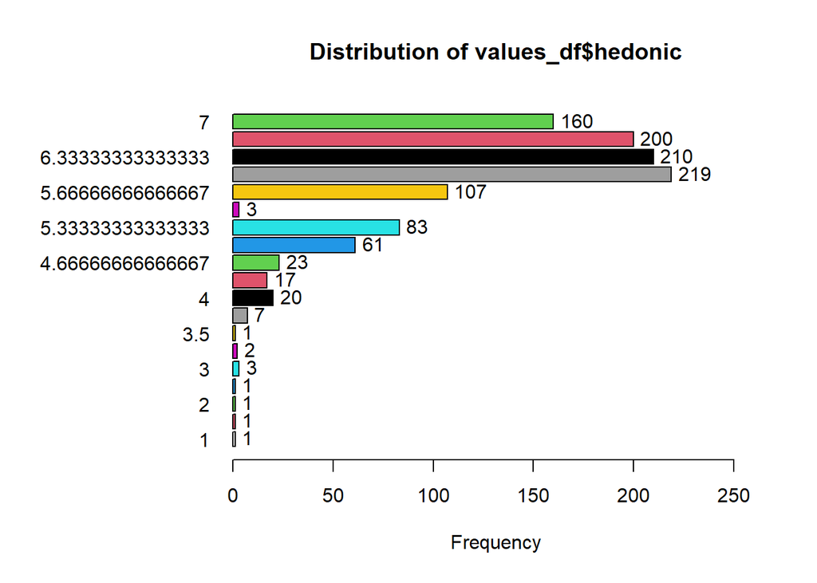

```
## values_df$hedonic :
##                  Frequency   %(NA+) cum.%(NA+)   %(NA-) cum.%(NA-)
## 1                        1      0.1        0.1      0.1        0.1
## 1.66666666666667         1      0.1        0.2      0.1        0.2
## 2                        1      0.1        0.3      0.1        0.3
## 2.33333333333333         1      0.1        0.4      0.1        0.4
## 3                        3      0.3        0.6      0.3        0.6
## 3.33333333333333         2      0.2        0.8      0.2        0.8
## 3.5                      1      0.1        0.9      0.1        0.9
## 3.66666666666667         7      0.6        1.5      0.6        1.5
## 4                       20      1.8        3.3      1.8        3.3
## 4.33333333333333        17      1.5        4.8      1.5        4.8
## 4.66666666666667        23      2.0        6.8      2.1        6.9
## 5                       61      5.4       12.2      5.4       12.3
## 5.33333333333333        83      7.3       19.5      7.4       19.7
## 5.5                      3      0.3       19.8      0.3       20.0
## 5.66666666666667       107      9.4       29.2      9.6       29.6
## 6                      219     19.3       48.5     19.6       49.1
## 6.33333333333333       210     18.5       67.1     18.8       67.9
## 6.66666666666667       200     17.7       84.7     17.9       85.7
## 7                      160     14.1       98.9     14.3      100.0
## NaN                     13      1.1      100.0      0.0      100.0
##   Total               1133    100.0      100.0    100.0      100.0
```

```r
# Hedonic values
tab1(values_df$hedonic, sort.group = "descending", cum.percent = TRUE, missing = FALSE, horiz = TRUE)
```

## Socially Desirable Responding

### Reverse-code

```r
data_R <- data_R %>%
  mutate(across(c(socially_desirable_1,
                  socially_desirable_3,
                  socially_desirable_5,
                  socially_desirable_8,
                  socially_desirable_9,
                  socially_desirable_11,
                  socially_desirable_12,
                  socially_desirable_13), ~8 - .)) # replace '#' with the max possible value plus 1 for any particular scale
```

### Average items

```r
data_R$self_deceptive_sdr <- data_R %>%
  dplyr::select(socially_desirable_1:socially_desirable_8) %>%
  rowMeans(na.rm = TRUE)

data_R$impress_manag_sdr <- data_R %>%
  dplyr::select(socially_desirable_9:socially_desirable_16) %>%
  rowMeans(na.rm = TRUE)
```

### Visually inspect

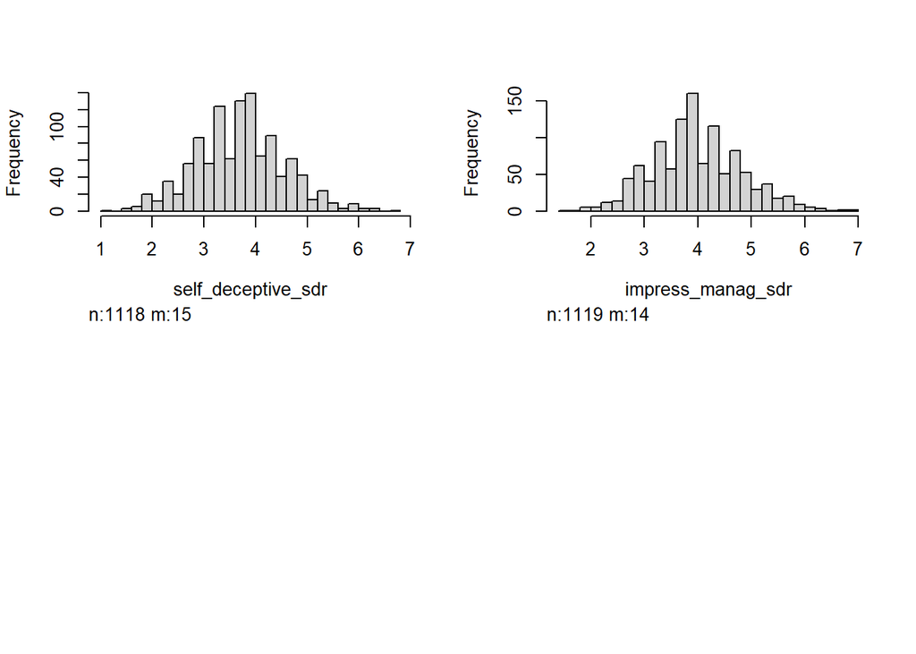

```r
data_R %>%
  dplyr::select(self_deceptive_sdr, impress_manag_sdr) %>%
  hist()
```

## Consumer Intentions

### Reverse-code

Higher scores mean better consumer intentions (intentions to *reduce* future consumption):

```r
data_R <- data_R %>%
  mutate(across(c(consumer_intentions_2,
                  consumer_intentions_4,
                  consumer_intentions_7,
                  consumer_intentions_9), ~8 - .)) # replace '#' with the max possible value plus 1 for any particular scale
```

### Average items

```r
data_R$consumer_intentions <- data_R %>%
  dplyr::select(consumer_intentions_1:consumer_intentions_9) %>%
  rowMeans(na.rm = TRUE)
```

### Visually inspect

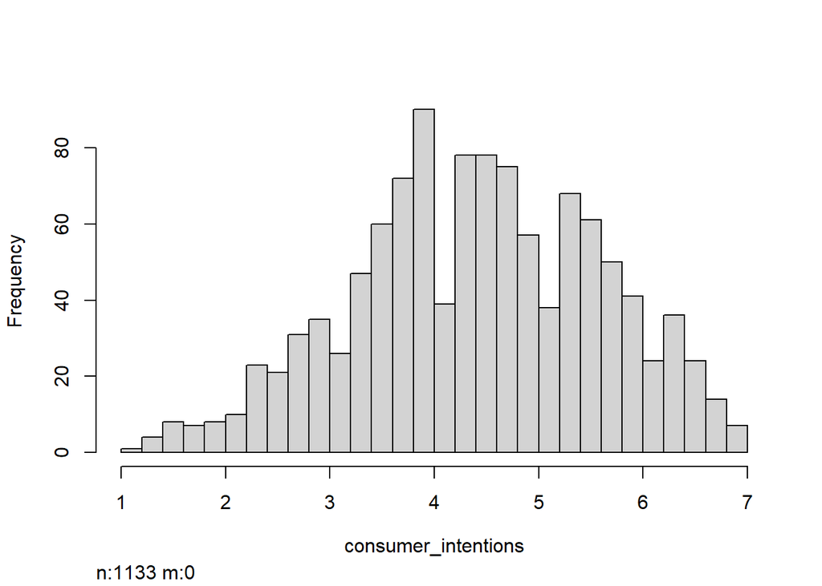

```r
data_R %>%
  dplyr::select(consumer_intentions) %>%
  hist()
```

### Reorder levels

Reorder the levels of norm condition:

```r
data_R %>%
  group_by(norm_condition) %>%
  summarize(M = mean(consumer_intentions, na.rm = TRUE))
```

```
## # A tibble: 5 × 2
##   norm_condition       M
##   <fct>            <dbl>
## 1 control_norm      4.46
## 2 convention_norm   4.55
## 3 descriptive_norm  4.42
## 4 moral_norm        4.34
## 5 social_norm       4.30
```

```r
data_R$norm_condition <- factor(data_R$norm_condition, levels = c("control_norm", "descriptive_norm", "convention_norm", "social_norm", "moral_norm"))
```

# Regression Analysis (DV = Consumer Intentions)

## Contrast Coding

Subset variables

Contrast Coding using ifelse() approach:

```r
# Framing
data_R_alt$FramingCode1 <- ifelse(data_R_alt$framing_condition == "control_framing", -1/2, ifelse(data_R_alt$framing_condition == "self_enh_framing", 1/2, 0))

data_R_alt$FramingCode2 <- ifelse(data_R_alt$framing_condition == "pro_env_framing", 2/3, -1/3)


# Norm
data_R_alt$NormCode1 <- ifelse(data_R_alt$norm_condition == "moral_norm", 4, -1)

data_R_alt$NormCode2 <- ifelse(data_R_alt$norm_condition == "social_norm", 3, ifelse(data_R_alt$norm_condition == "moral_norm", 0, -1))

data_R_alt$NormCode3 <- ifelse(data_R_alt$norm_condition == "convention_norm", 2, ifelse(data_R_alt$norm_condition == "moral_norm", 0, ifelse(data_R_alt$norm_condition == "social_norm", 0, -1)))
data_R_alt$NormCode4 <- ifelse(data_R_alt$norm_condition == "descriptive_norm", 1, ifelse(data_R_alt$norm_condition == "control_norm", -1, 0))


## Adding contrast codes to Framing & Norm Condition
# Framing
FrameCode1 <- c(-1/2, 0, 1/2) # control vs self-enhancing
FrameCode2 <- c(-1/3, 2/3, -1/3) # arbitrary code

contrasts(data_R_alt$framing_condition) <- cbind(FrameCode1, FrameCode2)
contrasts(data_R_alt$framing_condition)
```

```
##                  FrameCode1 FrameCode2
## control_framing        -0.5 -0.3333333
## pro_env_framing         0.0  0.6666667
## self_enh_framing        0.5 -0.3333333
```

```r
# Norm
contrasts(data_R_alt$norm_condition) <- contr.helmert(5)
contrasts(data_R_alt$norm_condition) # control vs DN
```

```
##                  [,1] [,2] [,3] [,4]
## control_norm       -1   -1   -1   -1
## descriptive_norm    1   -1   -1   -1
## convention_norm     0    2   -1   -1
## social_norm         0    0    3   -1
## moral_norm          0    0    0    4
```

```r
# Gender
levels(data_R_alt$Gender) <- c("Woman", "Man", "Non-binary", "I prefer not to identify", "Other")

data_R_alt$Gender[data_R_alt$Gender == "Non-binary"] <- NA
data_R_alt$Gender[data_R_alt$Gender == "I prefer not to identify"] <- NA
data_R_alt$Gender[data_R_alt$Gender == "Other"] <- NA

data_R_alt$Gender <- droplevels(data_R_alt$Gender)

contrasts(data_R_alt$Gender) <- c(1, 0)
levels(data_R_alt$Gender)
```

```
## [1] "Woman" "Man"
```

## Multiple Imputation

### Full Model

Examine missingness:

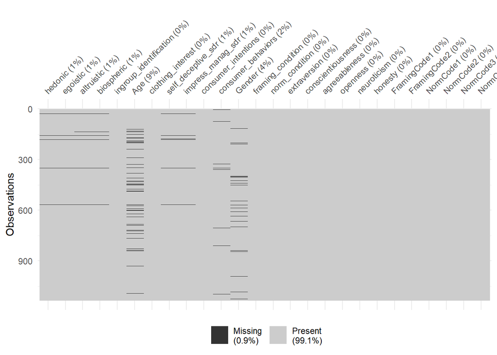

```r
data_R_alt %>%
  vis_miss()
```

```r
sapply(data_R_alt, function(x) sum(is.na(x)))
```

```
##                hedonic               egoistic             altruistic
##                     13                     14                     13
##             biospheric ingroup_identification                    Age
##                     14                      0                    103
##      clothing_interest     self_deceptive_sdr      impress_manag_sdr
##                      0                     15                     14
##    consumer_intentions     consumer_behaviors                 Gender
##                      0                     18                     41
##      framing_condition         norm_condition           extraversion
##                      0                      0                      2
##      conscientiousness          agreeableness               openness
##                      2                      2                      2
##            neuroticism                honesty           FramingCode1
##                      2                      2                      0
##           FramingCode2              NormCode1              NormCode2
##                      0                      0                      0
##              NormCode3              NormCode4
##                      0                      0
```

Variables with NO missing data:

- ingroup_identification
- clothing_interest
- consumer_intentions
- framing_condition
- norm_condition

Adding interaction terms

Imputation model

```r
set.seed(114950518)
```

- check out mice.impute.smcfcs

```
## [1] "Outcome variable(s): consumer_intentions"
## [1] "Passive variables: framing1Xbiospheric,framing2Xbiospheric,norm1Xbiospheric,norm2Xbiospheric,norm3Xbiospheric,norm4Xbiospheric,framing1Xnorm1Xbiospheric,framing1Xnorm2Xbiospheric,framing1Xnorm3Xbiospheric,framing1Xnorm4Xbiospheric,framing2Xnorm1Xbiospheric,framing2Xnorm2Xbiospheric,framing2X…
## [1] "Partially obs. variables: hedonic,egoistic,altruistic,biospheric,Age,self_deceptive_sdr,impress_manag_sdr,consumer_behaviors,Gender,extraversion,conscientiousness,agreeableness,openness,neuroticism,honesty"
## [1] "Fully obs. substantive model variables: ingroup_identification,clothing_interest,framing_condition,norm_condition,framing1Xingroup,framing2Xingroup,norm1Xingroup,norm2Xingroup,norm3Xingroup,norm4Xingroup,framing1Xnorm1Xingroup,framing1Xnorm2Xingroup,framing1Xnorm3Xingroup,framing1Xnorm4Xingr…
## [1] "Imputation  1"
## [1] "Imputing:  hedonic  using  egoistic,altruistic,biospheric,Age,self_deceptive_sdr,impress_manag_sdr,consumer_behaviors,Gender,extraversion,conscientiousness,agreeableness,openness,neuroticism,honesty,ingroup_identification,clothing_interest,framing_condition,norm_condition,framing1Xingroup,fr…
## [1] "Imputing:  egoistic  using  hedonic,altruistic,biospheric,Age,self_deceptive_sdr,impress_manag_sdr,consumer_behaviors,Gender,extraversion,conscientiousness,agreeableness,openness,neuroticism,honesty,ingroup_identification,clothing_interest,framing_condition,norm_condition,framing1Xingroup,fr…
## [1] "Imputing:  altruistic  using  hedonic,egoistic,biospheric,Age,self_deceptive_sdr,impress_manag_sdr,consumer_behaviors,Gender,extraversion,conscientiousness,agreeableness,openness,neuroticism,honesty,ingroup_identification,clothing_interest,framing_condition,norm_condition,framing1Xingroup,fr…
## [1] "Imputing:  biospheric  using  hedonic,egoistic,altruistic,Age,self_deceptive_sdr,impress_manag_sdr,consumer_behaviors,Gender,extraversion,conscientiousness,agreeableness,openness,neuroticism,honesty,ingroup_identification,clothing_interest,framing_condition,norm_condition,framing1Xingroup,fr…
## [1] "Imputing:  Age  using  hedonic,egoistic,altruistic,biospheric,self_deceptive_sdr,impress_manag_sdr,consumer_behaviors,Gender,extraversion,conscientiousness,agreeableness,openness,neuroticism,honesty,ingroup_identification,clothing_interest,framing_condition,norm_condition,framing1Xingroup,fr…
## [1] "Imputing:  self_deceptive_sdr  using  hedonic,egoistic,altruistic,biospheric,Age,impress_manag_sdr,consumer_behaviors,Gender,extraversion,conscientiousness,agreeableness,openness,neuroticism,honesty,ingroup_identification,clothing_interest,framing_condition,norm_condition,framing1Xingroup,fr…
## [1] "Imputing:  impress_manag_sdr  using  hedonic,egoistic,altruistic,biospheric,Age,self_deceptive_sdr,consumer_behaviors,Gender,extraversion,conscientiousness,agreeableness,openness,neuroticism,honesty,ingroup_identification,clothing_interest,framing_condition,norm_condition,framing1Xingroup,fr…
## [1] "Imputing:  consumer_behaviors  using  hedonic,egoistic,altruistic,biospheric,Age,self_deceptive_sdr,impress_manag_sdr,Gender,extraversion,conscientiousness,agreeableness,openness,neuroticism,honesty,ingroup_identification,clothing_interest,framing_condition,norm_condition,framing1Xingroup,fr…
## [1] "Imputing:  Gender  using  hedonic,egoistic,altruistic,biospheric,Age,self_deceptive_sdr,impress_manag_sdr,consumer_behaviors,extraversion,conscientiousness,agreeableness,openness,neuroticism,honesty,ingroup_identification,clothing_interest,framing_condition,norm_condition,framing1Xingroup,fr…
## [1] "Imputing:  extraversion  using  hedonic,egoistic,altruistic,biospheric,Age,self_deceptive_sdr,impress_manag_sdr,consumer_behaviors,Gender,conscientiousness,agreeableness,openness,neuroticism,honesty,ingroup_identification,clothing_interest,framing_condition,norm_condition,framing1Xingroup,fr…
## [1] "Imputing:  conscientiousness  using  hedonic,egoistic,altruistic,biospheric,Age,self_deceptive_sdr,impress_manag_sdr,consumer_behaviors,Gender,extraversion,agreeableness,openness,neuroticism,honesty,ingroup_identification,clothing_interest,framing_condition,norm_condition,framing1Xingroup,fr…
## [1] "Imputing:  agreeableness  using  hedonic,egoistic,altruistic,biospheric,Age,self_deceptive_sdr,impress_manag_sdr,consumer_behaviors,Gender,extraversion,conscientiousness,openness,neuroticism,honesty,ingroup_identification,clothing_interest,framing_condition,norm_condition,framing1Xingroup,fr…
## [1] "Imputing:  openness  using  hedonic,egoistic,altruistic,biospheric,Age,self_deceptive_sdr,impress_manag_sdr,consumer_behaviors,Gender,extraversion,conscientiousness,agreeableness,neuroticism,honesty,ingroup_identification,clothing_interest,framing_condition,norm_condition,framing1Xingroup,fr…
## [1] "Imputing:  neuroticism  using  hedonic,egoistic,altruistic,biospheric,Age,self_deceptive_sdr,impress_manag_sdr,consumer_behaviors,Gender,extraversion,conscientiousness,agreeableness,openness,honesty,ingroup_identification,clothing_interest,framing_condition,norm_condition,framing1Xingroup,fr…
## [1] "Imputing:  honesty  using  hedonic,egoistic,altruistic,biospheric,Age,self_deceptive_sdr,impress_manag_sdr,consumer_behaviors,Gender,extraversion,conscientiousness,agreeableness,openness,neuroticism,ingroup_identification,clothing_interest,framing_condition,norm_condition,framing1Xingroup,fr…
## [1] "Imputation  2"
## [1] "Imputation  3"
## [1] "Imputation  4"
## [1] "Imputation  5"
```

Storing imputed data sets

```r
impobject <- imputationList(imps$impDatasets)
```

### Centering continuous predictors

```r
# Biospheric values
impobject$imputations[[1]]$biospheric_center <- impobject$imputations[[1]]$biospheric - mean(impobject$imputations[[1]]$biospheric)

impobject$imputations[[2]]$biospheric_center <- impobject$imputations[[2]]$biospheric - mean(impobject$imputations[[2]]$biospheric)

impobject$imputations[[3]]$biospheric_center <- impobject$imputations[[3]]$biospheric - mean(impobject$imputations[[3]]$biospheric)

impobject$imputations[[4]]$biospheric_center <- impobject$imputations[[4]]$biospheric - mean(impobject$imputations[[4]]$biospheric)

impobject$imputations[[5]]$biospheric_center <- impobject$imputations[[5]]$biospheric - mean(impobject$imputations[[5]]$biospheric)


# Altruistic values
impobject$imputations[[1]]$altruistic_center <- impobject$imputations[[1]]$altruistic - mean(impobject$imputations[[1]]$altruistic)

impobject$imputations[[2]]$altruistic_center <- impobject$imputations[[2]]$altruistic - mean(impobject$imputations[[2]]$altruistic)

impobject$imputations[[3]]$altruistic_center <- impobject$imputations[[3]]$altruistic - mean(impobject$imputations[[3]]$altruistic)

impobject$imputations[[4]]$altruistic_center <- impobject$imputations[[4]]$altruistic - mean(impobject$imputations[[4]]$altruistic)

impobject$imputations[[5]]$altruistic_center <- impobject$imputations[[5]]$altruistic - mean(impobject$imputations[[5]]$altruistic)


# Egoistic values
impobject$imputations[[1]]$egoistic_center <- impobject$imputations[[1]]$egoistic - mean(impobject$imputations[[1]]$egoistic)

impobject$imputations[[2]]$egoistic_center <- impobject$imputations[[2]]$egoistic - mean(impobject$imputations[[2]]$egoistic)

impobject$imputations[[3]]$egoistic_center <- impobject$imputations[[3]]$egoistic - mean(impobject$imputations[[3]]$egoistic)

impobject$imputations[[4]]$egoistic_center <- impobject$imputations[[4]]$egoistic - mean(impobject$imputations[[4]]$egoistic)

impobject$imputations[[5]]$egoistic_center <- impobject$imputations[[5]]$egoistic - mean(impobject$imputations[[5]]$egoistic)


# Hedonic values
impobject$imputations[[1]]$hedonic_center <- impobject$imputations[[1]]$hedonic - mean(impobject$imputations[[1]]$hedonic)

impobject$imputations[[2]]$hedonic_center <- impobject$imputations[[2]]$hedonic - mean(impobject$imputations[[2]]$hedonic)

impobject$imputations[[3]]$hedonic_center <- impobject$imputations[[3]]$hedonic - mean(impobject$imputations[[3]]$hedonic)

impobject$imputations[[4]]$hedonic_center <- impobject$imputations[[4]]$hedonic - mean(impobject$imputations[[4]]$hedonic)

impobject$imputations[[5]]$hedonic_center <- impobject$imputations[[5]]$hedonic - mean(impobject$imputations[[5]]$hedonic)



# Ingroup identification
impobject$imputations[[1]]$ingroup_center <- impobject$imputations[[1]]$ingroup_identification - mean(impobject$imputations[[1]]$ingroup_identification)

impobject$imputations[[2]]$ingroup_center <- impobject$imputations[[2]]$ingroup_identification - mean(impobject$imputations[[2]]$ingroup_identification)

impobject$imputations[[3]]$ingroup_center <- impobject$imputations[[3]]$ingroup_identification - mean(impobject$imputations[[3]]$ingroup_identification)

impobject$imputations[[4]]$ingroup_center <- impobject$imputations[[4]]$ingroup_identification - mean(impobject$imputations[[4]]$ingroup_identification)

impobject$imputations[[5]]$ingroup_center <- impobject$imputations[[5]]$ingroup_identification - mean(impobject$imputations[[5]]$ingroup_identification)


# Age
impobject$imputations[[1]]$Age_center <- impobject$imputations[[1]]$Age - mean(impobject$imputations[[1]]$Age)

impobject$imputations[[2]]$Age_center <- impobject$imputations[[2]]$Age - mean(impobject$imputations[[2]]$Age)

impobject$imputations[[3]]$Age_center <- impobject$imputations[[3]]$Age - mean(impobject$imputations[[3]]$Age)

impobject$imputations[[4]]$Age_center <- impobject$imputations[[4]]$Age - mean(impobject$imputations[[4]]$Age)

impobject$imputations[[5]]$Age_center <- impobject$imputations[[5]]$Age - mean(impobject$imputations[[5]]$Age)



# Clothing interest
impobject$imputations[[1]]$clothing_center <- impobject$imputations[[1]]$clothing_interest - mean(impobject$imputations[[1]]$clothing_interest)

impobject$imputations[[2]]$clothing_center <- impobject$imputations[[2]]$clothing_interest - mean(impobject$imputations[[2]]$clothing_interest)

impobject$imputations[[3]]$clothing_center <- impobject$imputations[[3]]$clothing_interest - mean(impobject$imputations[[3]]$clothing_interest)

impobject$imputations[[4]]$clothing_center <- impobject$imputations[[4]]$clothing_interest - mean(impobject$imputations[[4]]$clothing_interest)

impobject$imputations[[5]]$clothing_center <- impobject$imputations[[5]]$clothing_interest - mean(impobject$imputations[[5]]$clothing_interest)



# Self deceptive SDR
impobject$imputations[[1]]$self_dec_center <- impobject$imputations[[1]]$self_deceptive_sdr - mean(impobject$imputations[[1]]$self_deceptive_sdr)

impobject$imputations[[2]]$self_dec_center <- impobject$imputations[[2]]$self_deceptive_sdr - mean(impobject$imputations[[2]]$self_deceptive_sdr)

impobject$imputations[[3]]$self_dec_center <- impobject$imputations[[3]]$self_deceptive_sdr - mean(impobject$imputations[[3]]$self_deceptive_sdr)

impobject$imputations[[4]]$self_dec_center <- impobject$imputations[[4]]$self_deceptive_sdr - mean(impobject$imputations[[4]]$self_deceptive_sdr)

impobject$imputations[[5]]$self_dec_center <- impobject$imputations[[5]]$self_deceptive_sdr - mean(impobject$imputations[[5]]$self_deceptive_sdr)


# Impression management SDR
impobject$imputations[[1]]$impress_manag_center <- impobject$imputations[[1]]$impress_manag_sdr - mean(impobject$imputations[[1]]$impress_manag_sdr)

impobject$imputations[[2]]$impress_manag_center <- impobject$imputations[[2]]$impress_manag_sdr - mean(impobject$imputations[[2]]$impress_manag_sdr)

impobject$imputations[[3]]$impress_manag_center <- impobject$imputations[[3]]$impress_manag_sdr - mean(impobject$imputations[[3]]$impress_manag_sdr)

impobject$imputations[[4]]$impress_manag_center <- impobject$imputations[[4]]$impress_manag_sdr - mean(impobject$imputations[[4]]$impress_manag_sdr)

impobject$imputations[[5]]$impress_manag_center <- impobject$imputations[[5]]$impress_manag_sdr - mean(impobject$imputations[[5]]$impress_manag_sdr)

# Extraversion
impobject$imputations[[1]]$extraversion_center <- impobject$imputations[[1]]$extraversion - mean(impobject$imputations[[1]]$extraversion)

impobject$imputations[[2]]$extraversion_center <- impobject$imputations[[2]]$extraversion - mean(impobject$imputations[[2]]$extraversion)

impobject$imputations[[3]]$extraversion_center <- impobject$imputations[[3]]$extraversion - mean(impobject$imputations[[3]]$extraversion)

impobject$imputations[[4]]$extraversion_center <- impobject$imputations[[4]]$extraversion - mean(impobject$imputations[[4]]$extraversion)

impobject$imputations[[5]]$extraversion_center <- impobject$imputations[[5]]$extraversion - mean(impobject$imputations[[5]]$extraversion)

# Conscientiousness
impobject$imputations[[1]]$conscientiousness_center <- impobject$imputations[[1]]$conscientiousness - mean(impobject$imputations[[1]]$conscientiousness)

impobject$imputations[[2]]$conscientiousness_center <- impobject$imputations[[2]]$conscientiousness - mean(impobject$imputations[[2]]$conscientiousness)

impobject$imputations[[3]]$conscientiousness_center <- impobject$imputations[[3]]$conscientiousness - mean(impobject$imputations[[3]]$conscientiousness)

impobject$imputations[[4]]$conscientiousness_center <- impobject$imputations[[4]]$conscientiousness - mean(impobject$imputations[[4]]$conscientiousness)

impobject$imputations[[5]]$conscientiousness_center <- impobject$imputations[[5]]$conscientiousness - mean(impobject$imputations[[5]]$conscientiousness)

# Agreeableness
impobject$imputations[[1]]$agreeableness_center <- impobject$imputations[[1]]$agreeableness - mean(impobject$imputations[[1]]$agreeableness)

impobject$imputations[[2]]$agreeableness_center <- impobject$imputations[[2]]$agreeableness - mean(impobject$imputations[[2]]$agreeableness)

impobject$imputations[[3]]$agreeableness_center <- impobject$imputations[[3]]$agreeableness - mean(impobject$imputations[[3]]$agreeableness)

impobject$imputations[[4]]$agreeableness_center <- impobject$imputations[[4]]$agreeableness - mean(impobject$imputations[[4]]$agreeableness)

impobject$imputations[[5]]$agreeableness_center <- impobject$imputations[[5]]$agreeableness - mean(impobject$imputations[[5]]$agreeableness)

# Openness
impobject$imputations[[1]]$openness_center <- impobject$imputations[[1]]$openness - mean(impobject$imputations[[1]]$openness)

impobject$imputations[[2]]$openness_center <- impobject$imputations[[2]]$openness - mean(impobject$imputations[[2]]$openness)

impobject$imputations[[3]]$openness_center <- impobject$imputations[[3]]$openness - mean(impobject$imputations[[3]]$openness)

impobject$imputations[[4]]$openness_center <- impobject$imputations[[4]]$openness - mean(impobject$imputations[[4]]$openness)

impobject$imputations[[5]]$openness_center <- impobject$imputations[[5]]$openness - mean(impobject$imputations[[5]]$openness)

# Neuroticism
impobject$imputations[[1]]$neuroticism_center <- impobject$imputations[[1]]$neuroticism - mean(impobject$imputations[[1]]$neuroticism)

impobject$imputations[[2]]$neuroticism_center <- impobject$imputations[[2]]$neuroticism - mean(impobject$imputations[[2]]$neuroticism)

impobject$imputations[[3]]$neuroticism_center <- impobject$imputations[[3]]$neuroticism - mean(impobject$imputations[[3]]$neuroticism)

impobject$imputations[[4]]$neuroticism_center <- impobject$imputations[[4]]$neuroticism - mean(impobject$imputations[[4]]$neuroticism)

impobject$imputations[[5]]$neuroticism_center <- impobject$imputations[[5]]$neuroticism - mean(impobject$imputations[[5]]$neuroticism)

# Honesty
impobject$imputations[[1]]$honesty_center <- impobject$imputations[[1]]$honesty - mean(impobject$imputations[[1]]$honesty)

impobject$imputations[[2]]$honesty_center <- impobject$imputations[[2]]$honesty - mean(impobject$imputations[[2]]$honesty)

impobject$imputations[[3]]$honesty_center <- impobject$imputations[[3]]$honesty - mean(impobject$imputations[[3]]$honesty)

impobject$imputations[[4]]$honesty_center <- impobject$imputations[[4]]$honesty - mean(impobject$imputations[[4]]$honesty)

impobject$imputations[[5]]$honesty_center <- impobject$imputations[[5]]$honesty - mean(impobject$imputations[[5]]$honesty)
```

Convert `scmfcs` object to a `mids` object (to make the object compatible with `mice`, and thus, `emmeans`):

```r
mids_obj <- datlist2mids(impobject)
```

Complete data set:

## Running Model

```r
mod_mice <- with(mids_obj, lm(consumer_intentions ~ framing_condition*norm_condition*biospheric_center + framing_condition*norm_condition*altruistic_center + framing_condition*norm_condition*egoistic_center + framing_condition*norm_condition*hedonic_center + framing_condition*norm_condition*ingroup_center + framing_condition*norm_condition*extraversion_center + framing_condition*norm_condition*conscientiousness_center + framing_condition*norm_condition*agreeableness_center + framing_condition*norm_condition*openness_center + framing_condition*norm_condition*neuroticism_center + framing_condition*norm_condition*honesty_center + self_dec_center + impress_manag_center + clothing_center + Gender + Age_center))
```

```r
pool_obj <- pool(mod_mice)

pool_obj
```

```
## Class: mipo    m = 5
##                                                                     term m
## 1                                                            (Intercept) 5
## 2                                            framing_conditionFrameCode1 5
## 3                                            framing_conditionFrameCode2 5
## 4                                                        norm_condition1 5
## 5                                                        norm_condition2 5
## 6                                                        norm_condition3 5
## 7                                                        norm_condition4 5
## 8                                                      biospheric_center 5
## 9                                                      altruistic_center 5
## 10                                                       egoistic_center 5
## 11                                                        hedonic_center 5
## 12                                                        ingroup_center 5
## 13                                                   extraversion_center 5
```

[output cut: 544 more lines]

## Pooled Regression Results

Using `mice` package:

```r
# summary(pool(mod_mice))

pool_summ <- summary(pool(mod_mice)) %>%
  knitr::kable(digits = 5)

pool_summ
```

| term | estimate | std.error | statistic | df | p.value |
| --- | --- | --- | --- | --- | --- |
| (Intercept) | 4.32417 | 0.06082 | 71.09559 | 859.6880 | 0.00000 |
| framing_conditionFrameCode1 | 0.03794 | 0.08169 | 0.46447 | 941.4279 | 0.64242 |
| framing_conditionFrameCode2 | 0.15298 | 0.06982 | 2.19100 | 944.1114 | 0.02870 |
| norm_condition1 | -0.00575 | 0.05072 | -0.11331 | 939.3857 | 0.90981 |
| norm_condition2 | 0.03948 | 0.03003 | 1.31464 | 942.0655 | 0.18895 |
| norm_condition3 | -0.04114 | 0.02163 | -1.90215 | 939.3371 | 0.05746 |
| norm_condition4 | -0.01170 | 0.01687 | -0.69380 | 935.6664 | 0.48798 |
| biospheric_center | 0.25649 | 0.04747 | 5.40302 | 935.2208 | 0.00000 |
| altruistic_center | 0.07233 | 0.06419 | 1.12688 | 934.7453 | 0.26008 |
| egoistic_center | -0.22704 | 0.04540 | -5.00032 | 881.1105 | 0.00000 |
| hedonic_center | -0.09940 | 0.05657 | -1.75716 | 433.1642 | 0.07960 |
| ingroup_center | 0.05086 | 0.03522 | 1.44427 | 927.6685 | 0.14900 |
| extraversion_center | -0.04578 | 0.05772 | -0.79314 | 934.5082 | 0.42790 |
| conscientiousness_center | -0.06848 | 0.06281 | -1.09035 | 945.5035 | 0.27584 |
| agreeableness_center | 0.10010 | 0.07800 | 1.28341 | 929.1287 | 0.19967 |
| openness_center | 0.41847 | 0.06291 | 6.65189 | 897.5438 | 0.00000 |
| neuroticism_center | 0.16266 | 0.06074 | 2.67790 | 870.6635 | 0.00755 |
| honesty_center | -0.12346 | 0.05729 | -2.15510 | 862.6347 | 0.03143 |
| self_dec_center | -0.01436 | 0.05077 | -0.28293 | 926.5614 | 0.77729 |
| impress_manag_center | -0.00758 | 0.04676 | -0.16205 | 807.6995 | 0.87131 |
| clothing_center | -0.04826 | 0.04642 | -1.03957 | 928.7908 | 0.29881 |
| Gender1 | 0.13396 | 0.08197 | 1.63430 | 821.6168 | 0.10258 |
| Age_center | -0.04835 | 0.01982 | -2.43968 | 109.2171 | 0.01631 |
| framing_conditionFrameCode1:norm_condition1 | 0.13705 | 0.12398 | 1.10540 | 927.7597 | 0.26927 |
| framing_conditionFrameCode2:norm_condition1 | -0.13166 | 0.10891 | -1.20885 | 944.6377 | 0.22702 |
| framing_conditionFrameCode1:norm_condition2 | -0.00157 | 0.07490 | -0.02090 | 939.2507 | 0.98333 |
| framing_conditionFrameCode2:norm_condition2 | -0.05074 | 0.06282 | -0.80776 | 941.4687 | 0.41943 |
| framing_conditionFrameCode1:norm_condition3 | 0.00910 | 0.05191 | 0.17528 | 939.1696 | 0.86090 |
| framing_conditionFrameCode2:norm_condition3 | 0.00538 | 0.04690 | 0.11479 | 944.8551 | 0.90864 |
| framing_conditionFrameCode1:norm_condition4 | 0.02925 | 0.04302 | 0.68001 | 940.1678 | 0.49666 |

[output cut: 155 more lines]

## Pooled Anova Results

```
## Univariate ANOVA for Multiply Imputed Data (Type 3)
##
## lm Formula:  consumer_intentions ~ framing_condition*norm_condition*biospheric_center + framing_condition*norm_condition*altruistic_center + framing_condition*norm_condition*egoistic_center + framing_condition*norm_condition*hedonic_center + framing_condition*norm_condition*ingroup_center + frami…
## R^2=0.2746
## ..........................................................................
## ANOVA Table
##                                                                 SSQ df1
## framing_condition                                           5.20631   2
## norm_condition                                              6.03133   4
## biospheric_center                                          30.54460   1
## altruistic_center                                           1.33320   1
## egoistic_center                                            26.44699   1
## hedonic_center                                              3.49757   1
## ingroup_center                                              2.19203   1
## extraversion_center                                         0.66200   1
## conscientiousness_center                                    1.23821   1
## agreeableness_center                                        1.73118   1
## openness_center                                            46.67196   1
## neuroticism_center                                          7.60542   1
## honesty_center                                              4.93755   1
## self_dec_center                                             0.08930   1
## impress_manag_center                                        0.04555   1
## clothing_center                                             1.13739   1
## Gender                                                      2.86301   1
## Age_center                                                  7.66891   1
## framing_condition:norm_condition                            4.48544   8
## framing_condition:biospheric_center                         0.27328   2
## norm_condition:biospheric_center                            9.12182   4
## framing_condition:altruistic_center                         1.48061   2
## norm_condition:altruistic_center                            7.73992   4
## framing_condition:egoistic_center                           0.35313   2
## norm_condition:egoistic_center                              1.89805   4
## framing_condition:hedonic_center                            1.70510   2
## norm_condition:hedonic_center                               7.77926   4
## framing_condition:ingroup_center                            0.17560   2
## norm_condition:ingroup_center                               2.14835   4
## framing_condition:extraversion_center                       1.53404   2
## norm_condition:extraversion_center                          4.59344   4
## framing_condition:conscientiousness_center                  7.10708   2
## norm_condition:conscientiousness_center                    16.63586   4
```

[output cut: 167 more lines]

```
## norm_condition:neuroticism_center                              0.00448
## framing_condition:honesty_center                               0.00166
## norm_condition:honesty_center                                  0.00560
## framing_condition:norm_condition:biospheric_center             0.02021
## framing_condition:norm_condition:altruistic_center             0.00954
## framing_condition:norm_condition:egoistic_center               0.00578
## framing_condition:norm_condition:hedonic_center                0.00487
## framing_condition:norm_condition:ingroup_center                0.01182
## framing_condition:norm_condition:extraversion_center           0.01629
## framing_condition:norm_condition:conscientiousness_center      0.01137
## framing_condition:norm_condition:agreeableness_center          0.01285
## framing_condition:norm_condition:openness_center               0.01898
## framing_condition:norm_condition:neuroticism_center            0.01480
## framing_condition:norm_condition:honesty_center                0.00779
## Residual                                                            NA
```

```r
anova_pool %>%
  knitr::kable(digits = 3)
```

| x |
| --- |
| 0.275 |

|  | SSQ | df1 | df2 | F value | Pr(>F) | eta2 | partial.eta2 |
| --- | --- | --- | --- | --- | --- | --- | --- |
| framing_condition | 5.206 | 2 | 2301234.633 | 2.497 | 0.082 | 0.004 | 0.005 |
| norm_condition | 6.031 | 4 | 397161.335 | 1.443 | 0.217 | 0.004 | 0.006 |
| biospheric_center | 30.545 | 1 | 120496.506 | 29.171 | 0.000 | 0.022 | 0.030 |
| altruistic_center | 1.333 | 1 | 104903.382 | 1.264 | 0.261 | 0.001 | 0.001 |
| egoistic_center | 26.447 | 1 | 16438.433 | 24.991 | 0.000 | 0.019 | 0.026 |
| hedonic_center | 3.498 | 1 | 898.669 | 3.037 | 0.082 | 0.003 | 0.004 |
| ingroup_center | 2.192 | 1 | 75044.580 | 2.080 | 0.149 | 0.002 | 0.002 |
| extraversion_center | 0.662 | 1 | 137206.681 | 0.625 | 0.429 | 0.000 | 0.001 |
| conscientiousness_center | 1.238 | 1 | 13862603.832 | 1.188 | 0.276 | 0.001 | 0.001 |
| agreeableness_center | 1.731 | 1 | 87334.997 | 1.642 | 0.200 | 0.001 | 0.002 |
| openness_center | 46.672 | 1 | 21098.376 | 44.208 | 0.000 | 0.034 | 0.045 |
| neuroticism_center | 7.605 | 1 | 15456.295 | 7.165 | 0.007 | 0.006 | 0.008 |
| honesty_center | 4.938 | 1 | 10903.429 | 4.625 | 0.032 | 0.004 | 0.005 |
| self_dec_center | 0.089 | 1 | 67821.285 | 0.074 | 0.786 | 0.000 | 0.000 |
| impress_manag_center | 0.046 | 1 | 6567.481 | 0.006 | 0.940 | 0.000 | 0.000 |
| clothing_center | 1.137 | 1 | 77707.684 | 1.075 | 0.300 | 0.001 | 0.001 |
| Gender | 2.863 | 1 | 6948.959 | 2.649 | 0.104 | 0.002 | 0.003 |
| Age_center | 7.669 | 1 | 132.578 | 5.832 | 0.017 | 0.006 | 0.008 |
| framing_condition:norm_condition | 4.485 | 8 | 36247.703 | 0.527 | 0.837 | 0.003 | 0.005 |
| framing_condition:biospheric_center | 0.273 | 2 | 43562.246 | 0.119 | 0.888 | 0.000 | 0.000 |
| norm_condition:biospheric_center | 9.122 | 4 | 36352.549 | 2.166 | 0.070 | 0.007 | 0.009 |
| framing_condition:altruistic_center | 1.481 | 2 | 56480.975 | 0.696 | 0.498 | 0.001 | 0.001 |
| norm_condition:altruistic_center | 7.740 | 4 | 5100.592 | 1.797 | 0.126 | 0.006 | 0.008 |
| framing_condition:egoistic_center | 0.353 | 2 | 26098885.134 | 0.169 | 0.844 | 0.000 | 0.000 |
| norm_condition:egoistic_center | 1.898 | 4 | 19360.544 | 0.438 | 0.782 | 0.001 | 0.002 |
| framing_condition:hedonic_center | 1.705 | 2 | 1163.474 | 0.709 | 0.492 | 0.001 | 0.002 |
| norm_condition:hedonic_center | 7.779 | 4 | 175076.691 | 1.858 | 0.115 | 0.006 | 0.008 |
| framing_condition:ingroup_center | 0.176 | 2 | 98005.132 | 0.076 | 0.927 | 0.000 | 0.000 |
| norm_condition:ingroup_center | 2.148 | 4 | 1355500.193 | 0.514 | 0.726 | 0.002 | 0.002 |
| framing_condition:extraversion_center | 1.534 | 2 | 134868.340 | 0.727 | 0.483 | 0.001 | 0.002 |
| norm_condition:extraversion_center | 4.593 | 4 | 456576.518 | 1.098 | 0.355 | 0.003 | 0.005 |
| framing_condition:conscientiousness_center | 7.107 | 2 | 513182.136 | 3.403 | 0.033 | 0.005 | 0.007 |
| norm_condition:conscientiousness_center | 16.636 | 4 | 640965.581 | 3.987 | 0.003 | 0.012 | 0.017 |
| framing_condition:agreeableness_center | 1.709 | 2 | 754457.587 | 0.817 | 0.442 | 0.001 | 0.002 |
| norm_condition:agreeableness_center | 2.289 | 4 | 5529126.983 | 0.549 | 0.700 | 0.002 | 0.002 |
| framing_condition:openness_center | 1.996 | 2 | 135464.191 | 0.948 | 0.387 | 0.001 | 0.002 |
| norm_condition:openness_center | 4.566 | 4 | 31744.648 | 1.078 | 0.366 | 0.003 | 0.005 |
| framing_condition:neuroticism_center | 0.016 | 2 | 1225433.816 | 0.005 | 0.995 | 0.000 | 0.000 |
| norm_condition:neuroticism_center | 4.441 | 4 | 54812.835 | 1.052 | 0.378 | 0.003 | 0.004 |
| framing_condition:honesty_center | 1.645 | 2 | 79612.684 | 0.777 | 0.460 | 0.001 | 0.002 |
| norm_condition:honesty_center | 5.554 | 4 | 42730.301 | 1.316 | 0.261 | 0.004 | 0.006 |
| framing_condition:norm_condition:biospheric_center | 20.355 | 8 | 86915.883 | 2.430 | 0.013 | 0.015 | 0.020 |
| framing_condition:norm_condition:altruistic_center | 9.507 | 8 | 2382.022 | 1.084 | 0.371 | 0.007 | 0.010 |
| framing_condition:norm_condition:egoistic_center | 5.733 | 8 | 5644.233 | 0.657 | 0.730 | 0.004 | 0.006 |
| framing_condition:norm_condition:hedonic_center | 4.826 | 8 | 148.997 | 0.397 | 0.921 | 0.004 | 0.005 |
| framing_condition:norm_condition:ingroup_center | 11.806 | 8 | 586821.046 | 1.414 | 0.185 | 0.009 | 0.012 |
| framing_condition:norm_condition:extraversion_center | 16.341 | 8 | 542387.679 | 1.958 | 0.047 | 0.012 | 0.016 |
| framing_condition:norm_condition:conscientiousness_center | 11.350 | 8 | 5611.775 | 1.322 | 0.227 | 0.008 | 0.011 |
| framing_condition:norm_condition:agreeableness_center | 12.839 | 8 | 220481.674 | 1.535 | 0.139 | 0.009 | 0.013 |
| framing_condition:norm_condition:openness_center | 19.085 | 8 | 38583.963 | 2.272 | 0.020 | 0.014 | 0.019 |
| framing_condition:norm_condition:neuroticism_center | 14.819 | 8 | 69769.842 | 1.766 | 0.078 | 0.011 | 0.015 |
| framing_condition:norm_condition:honesty_center | 7.744 | 8 | 12119.049 | 0.906 | 0.510 | 0.006 | 0.008 |
| Residual | 986.628 | NA | NA | NA | NA | NA | NA |

| x |
| --- |
| 3 |

# Simple Effects

## Personality Interactions

### Extraversion

First, relationship between extraversion & consumer intentions for each norm condition:

```r
emtrends(mod_mice, ~norm_condition, var = "extraversion_center", adjust = "none")
```

```
##  norm_condition   extraversion_center.trend    SE  df lower.CL upper.CL
##  control_norm                       -0.0414 0.112 948  -0.2612   0.1784
##  descriptive_norm                   -0.0851 0.135 948  -0.3506   0.1804
##  convention_norm                    -0.1839 0.119 948  -0.4178   0.0501
##  social_norm                         0.1671 0.126 948  -0.0802   0.4144
##  moral_norm                         -0.0857 0.141 948  -0.3630   0.1917
##
## Results are averaged over the levels of: framing_condition, Gender
## Confidence level used: 0.95
```

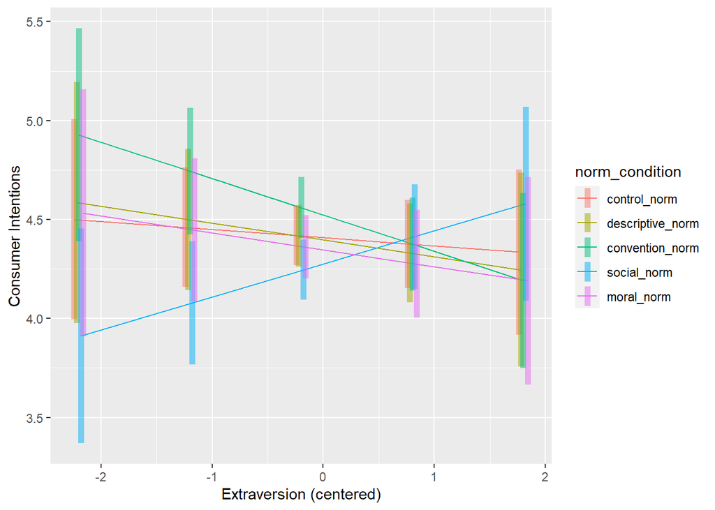

```r
# On a single graph
at_list <- list(extraversion_center = seq(-2.2, 2, by = 1))

emmip(mod_mice, norm_condition ~ extraversion_center, at = at_list, CIs = TRUE, xlab = "Extraversion (centered)", ylab = "Consumer Intentions")
```

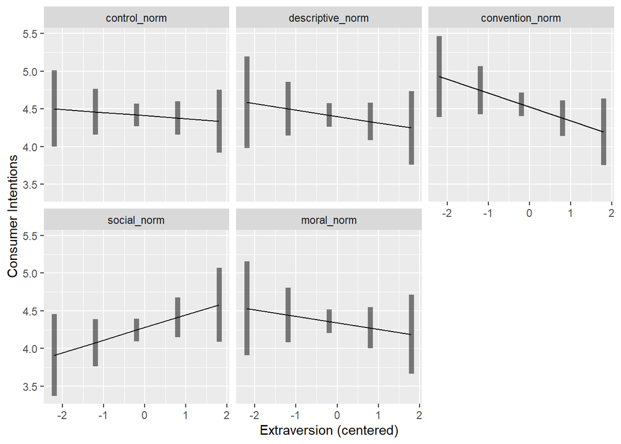

```r
# Separate graph for each norm
emmip(mod_mice, ~ extraversion_center | norm_condition, at = at_list, CIs = TRUE, xlab = "Extraversion (centered)", ylab = "Consumer Intentions")
```

Is the slope of the relationship between extraversion & consumer intentions stronger in any one of the norm conditions compared to the others?

```r
emtrends(mod_mice, pairwise~norm_condition, var = "extraversion_center", adjust = "none")
```

```
## $emtrends
##  norm_condition   extraversion_center.trend    SE  df lower.CL upper.CL
##  control_norm                       -0.0414 0.112 948  -0.2612   0.1784
##  descriptive_norm                   -0.0851 0.135 948  -0.3506   0.1804
##  convention_norm                    -0.1839 0.119 948  -0.4178   0.0501
##  social_norm                         0.1671 0.126 948  -0.0802   0.4144
##  moral_norm                         -0.0857 0.141 948  -0.3630   0.1917
##
## Results are averaged over the levels of: framing_condition, Gender
## Confidence level used: 0.95
##
## $contrasts
##  contrast                            estimate    SE  df t.ratio p.value
##  control_norm - descriptive_norm     0.043693 0.175 948   0.250  0.8030
##  control_norm - convention_norm      0.142468 0.163 948   0.875  0.3817
##  control_norm - social_norm         -0.208490 0.168 948  -1.240  0.2154
##  control_norm - moral_norm           0.044265 0.180 948   0.246  0.8054
##  descriptive_norm - convention_norm  0.098775 0.179 948   0.551  0.5821
##  descriptive_norm - social_norm     -0.252183 0.184 948  -1.370  0.1710
##  descriptive_norm - moral_norm       0.000572 0.195 948   0.003  0.9977
##  convention_norm - social_norm      -0.350958 0.173 948  -2.033  0.0423
##  convention_norm - moral_norm       -0.098203 0.184 948  -0.533  0.5939
##  social_norm - moral_norm            0.252756 0.189 948   1.338  0.1814
##
## Results are averaged over the levels of: framing_condition, Gender
```

Second, relationship between extraversion & consumer intentions for each framing condition:

```r
emtrends(mod_mice, ~framing_condition, var = "extraversion_center", adjust = "none")
```

```
##  framing_condition extraversion_center.trend     SE  df lower.CL upper.CL
##  control_framing                      0.0275 0.1002 948   -0.169   0.2241
##  pro_env_framing                     -0.1380 0.0991 948   -0.333   0.0566
##  self_enh_framing                    -0.0269 0.0978 948   -0.219   0.1651
##
## Results are averaged over the levels of: norm_condition, Gender
## Confidence level used: 0.95
```

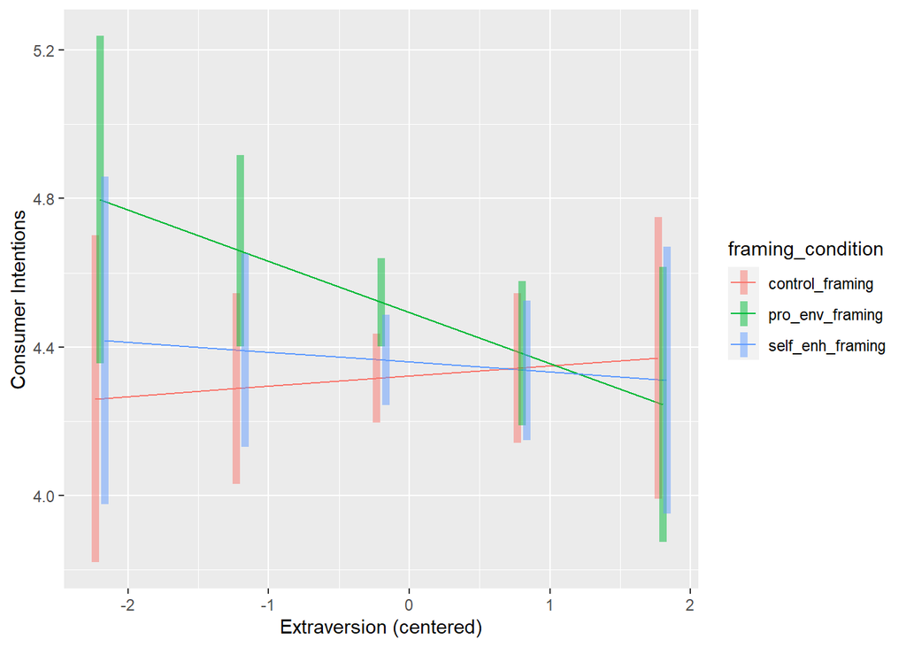

```r
# On a single graph
at_list <- list(extraversion_center = seq(-2.2, 2, by = 1))

emmip(mod_mice, framing_condition ~ extraversion_center, at = at_list, CIs = TRUE, xlab = "Extraversion (centered)", ylab = "Consumer Intentions")
```

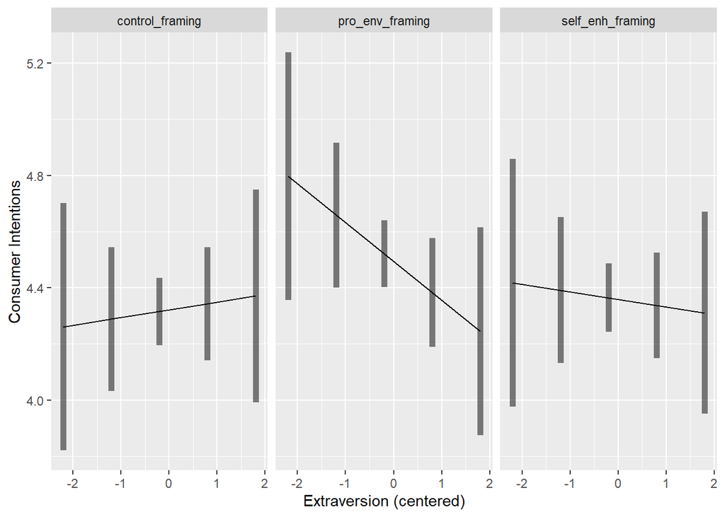

```r
# Separate graph for each norm
emmip(mod_mice, ~ extraversion_center | framing_condition, at = at_list, CIs = TRUE, xlab = "Extraversion (centered)", ylab = "Consumer Intentions")
```

Is the slope of the relationship between extraversion & consumer intentions stronger in any one of the framing conditions compared to the others?

```r
emtrends(mod_mice, pairwise~framing_condition, var = "extraversion_center", adjust = "none")
```

```
## $emtrends
##  framing_condition extraversion_center.trend     SE  df lower.CL upper.CL
##  control_framing                      0.0275 0.1002 948   -0.169   0.2241
##  pro_env_framing                     -0.1380 0.0991 948   -0.333   0.0566
##  self_enh_framing                    -0.0269 0.0978 948   -0.219   0.1651
##
## Results are averaged over the levels of: norm_condition, Gender
## Confidence level used: 0.95
##
## $contrasts
##  contrast                           estimate    SE  df t.ratio p.value
##  control_framing - pro_env_framing    0.1654 0.140 948   1.181  0.2380
##  control_framing - self_enh_framing   0.0543 0.139 948   0.391  0.6963
##  pro_env_framing - self_enh_framing  -0.1111 0.139 948  -0.799  0.4244
##
## Results are averaged over the levels of: norm_condition, Gender
```

Third, interaction between extraversion, framing, & norm condition:

```r
emtrends(mod_mice, ~norm_condition | framing_condition, var = "extraversion_center", adjust = "none")
```

```
## framing_condition = control_framing:
##  norm_condition   extraversion_center.trend    SE  df lower.CL upper.CL
##  control_norm                       0.40766 0.209 948  -0.0032  0.81852
##  descriptive_norm                   0.02468 0.253 948  -0.4727  0.52207
##  convention_norm                   -0.14131 0.220 948  -0.5738  0.29117
##  social_norm                       -0.05432 0.187 948  -0.4212  0.31251
##  moral_norm                        -0.09937 0.241 948  -0.5717  0.37297
##
## framing_condition = pro_env_framing:
##  norm_condition   extraversion_center.trend    SE  df lower.CL upper.CL
##  control_norm                      -0.26109 0.188 948  -0.6310  0.10879
##  descriptive_norm                  -0.37085 0.224 948  -0.8111  0.06940
##  convention_norm                   -0.00554 0.188 948  -0.3752  0.36415
##  social_norm                        0.02141 0.250 948  -0.4686  0.51140
##  moral_norm                        -0.07374 0.246 948  -0.5564  0.40889
##
## framing_condition = self_enh_framing:
##  norm_condition   extraversion_center.trend    SE  df lower.CL upper.CL
##  control_norm                      -0.27076 0.183 948  -0.6298  0.08830
##  descriptive_norm                   0.09089 0.223 948  -0.3463  0.52809
##  convention_norm                   -0.40475 0.207 948  -0.8107  0.00119
##  social_norm                        0.53419 0.212 948   0.1176  0.95079
##  moral_norm                        -0.08388 0.251 948  -0.5773  0.40959
##
## Results are averaged over the levels of: Gender
## Confidence level used: 0.95
```

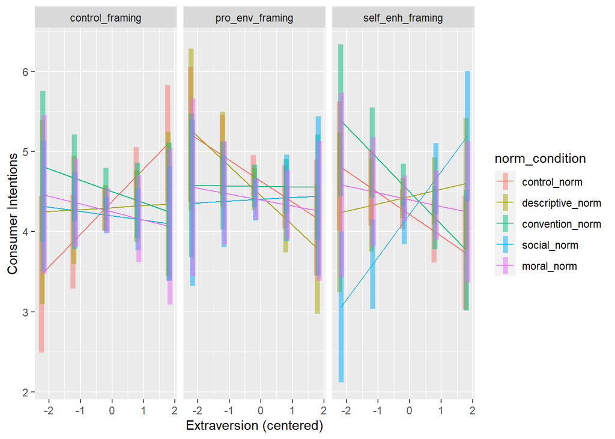

```r
# Separate graph for each framing condition
at_list <- list(extraversion_center = seq(-2.2, 2, by = 1))

emmip(mod_mice, norm_condition ~ extraversion_center | framing_condition, at = at_list, CIs = TRUE, xlab = "Extraversion (centered)", ylab = "Consumer Intentions")
```

### Agreeableness

First, relationship between agreeableness & consumer intentions for each norm condition:

```r
emtrends(mod_mice, ~norm_condition, var = "agreeableness_center", adjust = "none")
```

```
##  norm_condition   agreeableness_center.trend    SE  df lower.CL upper.CL
##  control_norm                         0.0565 0.164 948  -0.2663    0.379
##  descriptive_norm                     0.1001 0.182 948  -0.2571    0.457
##  convention_norm                      0.3214 0.179 948  -0.0297    0.673
##  social_norm                         -0.0111 0.174 948  -0.3523    0.330
##  moral_norm                           0.0336 0.156 948  -0.2731    0.340
##
## Results are averaged over the levels of: framing_condition, Gender
## Confidence level used: 0.95
```

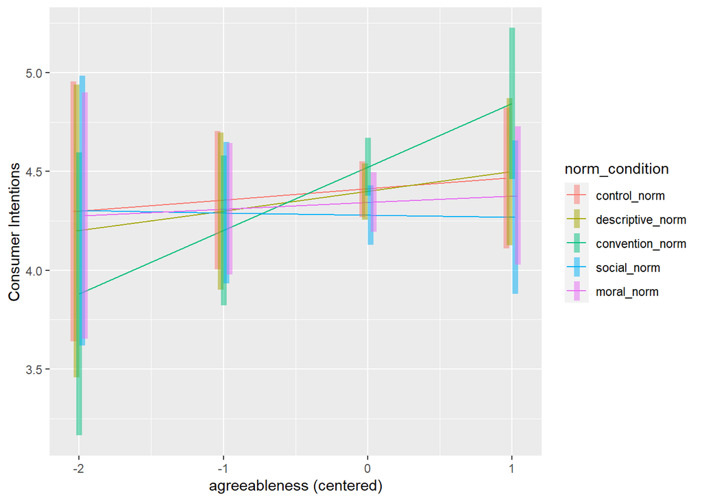

```r
# On a single graph
at_list <- list(agreeableness_center = seq(-2, 1.4, by = 1))

emmip(mod_mice, norm_condition ~ agreeableness_center, at = at_list, CIs = TRUE, xlab = "agreeableness (centered)", ylab = "Consumer Intentions")
```

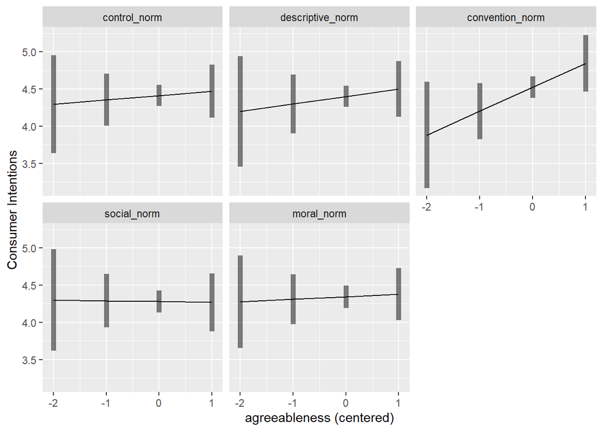

```r
# Separate graph for each norm
emmip(mod_mice, ~ agreeableness_center | norm_condition, at = at_list, CIs = TRUE, xlab = "agreeableness (centered)", ylab = "Consumer Intentions")
```

Is the slope of the relationship between agreeableness & consumer intentions stronger in any one of the norm conditions compared to the others?

```r
emtrends(mod_mice, pairwise~norm_condition, var = "agreeableness_center", adjust = "none")
```

```
## $emtrends
##  norm_condition   agreeableness_center.trend    SE  df lower.CL upper.CL
##  control_norm                         0.0565 0.164 948  -0.2663    0.379
##  descriptive_norm                     0.1001 0.182 948  -0.2571    0.457
##  convention_norm                      0.3214 0.179 948  -0.0297    0.673
##  social_norm                         -0.0111 0.174 948  -0.3523    0.330
##  moral_norm                           0.0336 0.156 948  -0.2731    0.340
##
## Results are averaged over the levels of: framing_condition, Gender
## Confidence level used: 0.95
##
## $contrasts
##  contrast                           estimate    SE  df t.ratio p.value
##  control_norm - descriptive_norm     -0.0435 0.243 948  -0.179  0.8580
##  control_norm - convention_norm      -0.2649 0.242 948  -1.093  0.2745
##  control_norm - social_norm           0.0676 0.238 948   0.284  0.7764
##  control_norm - moral_norm            0.0229 0.226 948   0.102  0.9191
##  descriptive_norm - convention_norm  -0.2214 0.255 948  -0.869  0.3851
##  descriptive_norm - social_norm       0.1112 0.251 948   0.444  0.6573
##  descriptive_norm - moral_norm        0.0665 0.239 948   0.278  0.7814
##  convention_norm - social_norm        0.3325 0.249 948   1.336  0.1820
##  convention_norm - moral_norm         0.2878 0.236 948   1.217  0.2238
##  social_norm - moral_norm            -0.0447 0.232 948  -0.193  0.8472
##
## Results are averaged over the levels of: framing_condition, Gender
```

Second, relationship between agreeableness & consumer intentions for each framing condition:

```r
emtrends(mod_mice, ~framing_condition, var = "agreeableness_center", adjust = "none")
```

```
##  framing_condition agreeableness_center.trend    SE  df lower.CL upper.CL
##  control_framing                       0.1632 0.129 948  -0.0906    0.417
##  pro_env_framing                      -0.0399 0.137 948  -0.3093    0.230
##  self_enh_framing                      0.1770 0.132 948  -0.0821    0.436
##
## Results are averaged over the levels of: norm_condition, Gender
## Confidence level used: 0.95
```

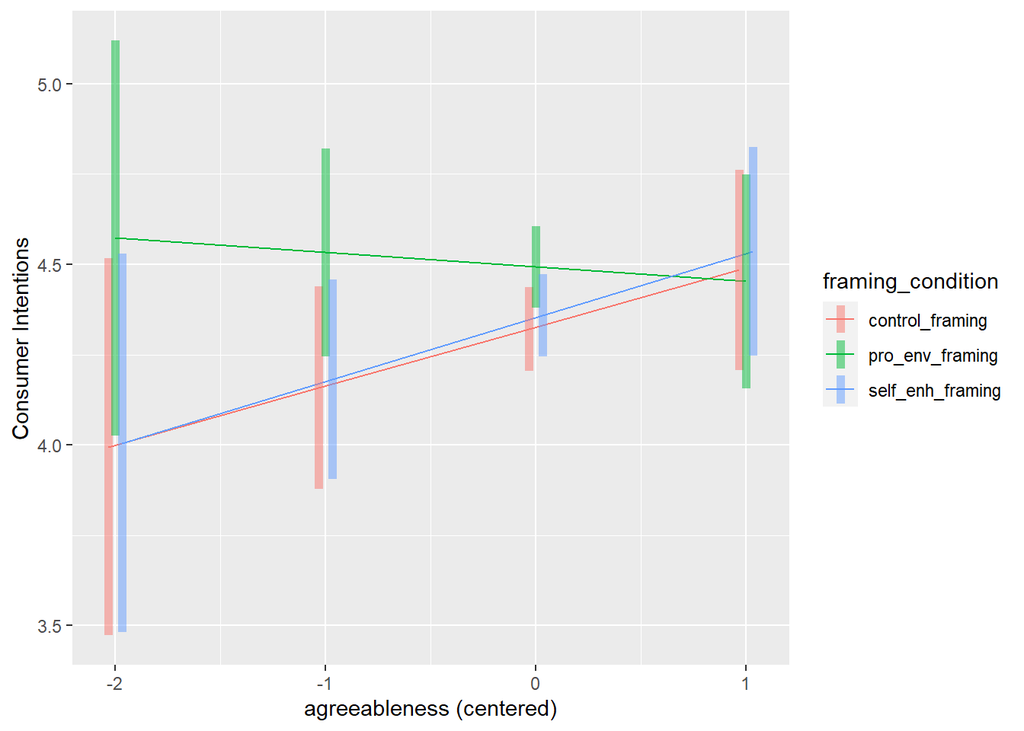

```r
# On a single graph
at_list <- list(agreeableness_center = seq(-2, 1.4, by = 1))

emmip(mod_mice, framing_condition ~ agreeableness_center, at = at_list, CIs = TRUE, xlab = "agreeableness (centered)", ylab = "Consumer Intentions")
```

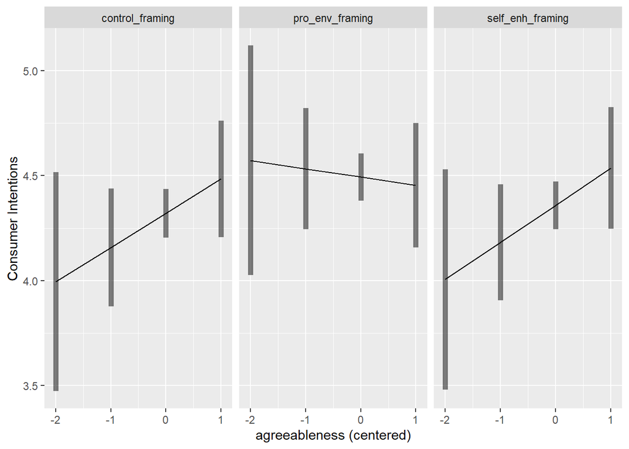

```r
# Separate graph for each norm
emmip(mod_mice, ~ agreeableness_center | framing_condition, at = at_list, CIs = TRUE, xlab = "agreeableness (centered)", ylab = "Consumer Intentions")
```

Is the slope of the relationship between agreeableness & consumer intentions stronger in any one of the framing conditions compared to the others?

```r
emtrends(mod_mice, pairwise~framing_condition, var = "agreeableness_center", adjust = "none")
```

```
## $emtrends
##  framing_condition agreeableness_center.trend    SE  df lower.CL upper.CL
##  control_framing                       0.1632 0.129 948  -0.0906    0.417
##  pro_env_framing                      -0.0399 0.137 948  -0.3093    0.230
##  self_enh_framing                      0.1770 0.132 948  -0.0821    0.436
##
## Results are averaged over the levels of: norm_condition, Gender
## Confidence level used: 0.95
##
## $contrasts
##  contrast                           estimate    SE  df t.ratio p.value
##  control_framing - pro_env_framing    0.2031 0.187 948   1.085  0.2784
##  control_framing - self_enh_framing  -0.0138 0.183 948  -0.075  0.9399
##  pro_env_framing - self_enh_framing  -0.2169 0.189 948  -1.148  0.2514
##
## Results are averaged over the levels of: norm_condition, Gender
```

Third, interaction between agreeableness, framing, & norm condition:

```r
emtrends(mod_mice, ~norm_condition | framing_condition, var = "agreeableness_center", adjust = "none")
```

```
## framing_condition = control_framing:
##  norm_condition   agreeableness_center.trend    SE  df lower.CL upper.CL
##  control_norm                         0.0543 0.276 948  -0.4866    0.595
##  descriptive_norm                     0.2371 0.292 948  -0.3362    0.810
##  convention_norm                      0.4854 0.350 948  -0.2013    1.172
##  social_norm                          0.4304 0.251 948  -0.0616    0.922
##  moral_norm                          -0.3912 0.259 948  -0.8986    0.116
##
## framing_condition = pro_env_framing:
##  norm_condition   agreeableness_center.trend    SE  df lower.CL upper.CL
##  control_norm                         0.2356 0.304 948  -0.3608    0.832
##  descriptive_norm                    -0.1686 0.342 948  -0.8388    0.502
##  convention_norm                     -0.1374 0.280 948  -0.6860    0.411
##  social_norm                         -0.3517 0.319 948  -0.9772    0.274
##  moral_norm                           0.2226 0.277 948  -0.3206    0.766
##
## framing_condition = self_enh_framing:
##  norm_condition   agreeableness_center.trend    SE  df lower.CL upper.CL
##  control_norm                        -0.1204 0.272 948  -0.6541    0.413
##  descriptive_norm                     0.2317 0.303 948  -0.3639    0.827
##  convention_norm                      0.6163 0.294 948   0.0400    1.193
##  social_norm                         -0.1120 0.326 948  -0.7525    0.528
##  moral_norm                           0.2694 0.272 948  -0.2642    0.803
##
## Results are averaged over the levels of: Gender
## Confidence level used: 0.95
```

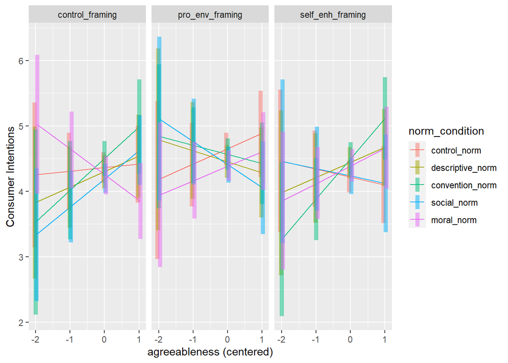

```r
# Separate graph for each framing condition
at_list <- list(agreeableness_center = seq(-2, 1.4, by = 1))

emmip(mod_mice, norm_condition ~ agreeableness_center | framing_condition, at = at_list, CIs = TRUE, xlab = "agreeableness (centered)", ylab = "Consumer Intentions")
```

### Openness

First, relationship between openness & consumer intentions for each norm condition:

```r
emtrends(mod_mice, ~norm_condition, var = "openness_center", adjust = "none")
```

```
##  norm_condition   openness_center.trend    SE  df lower.CL upper.CL
##  control_norm                     0.350 0.135 948   0.0845    0.616
##  descriptive_norm                 0.208 0.136 948  -0.0585    0.475
##  convention_norm                  0.437 0.135 948   0.1718    0.702
##  social_norm                      0.545 0.147 948   0.2563    0.834
##  moral_norm                       0.552 0.142 948   0.2736    0.830
##
## Results are averaged over the levels of: framing_condition, Gender
## Confidence level used: 0.95
```

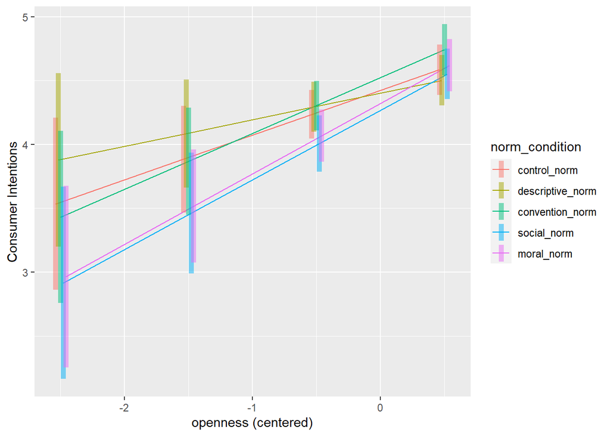

```r
# On a single graph
at_list <- list(openness_center = seq(-2.5, 1.4, by = 1))

emmip(mod_mice, norm_condition ~ openness_center, at = at_list, CIs = TRUE, xlab = "openness (centered)", ylab = "Consumer Intentions")
```

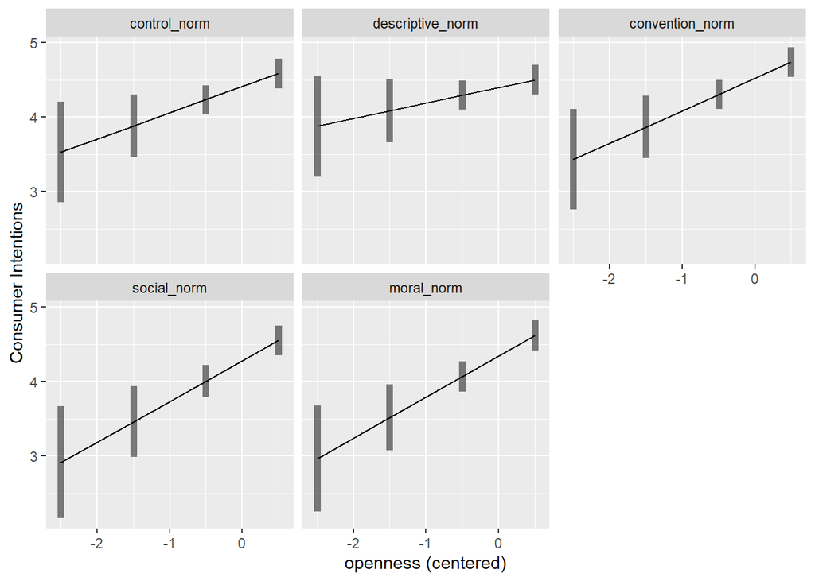

```r
# Separate graph for each norm
emmip(mod_mice, ~ openness_center | norm_condition, at = at_list, CIs = TRUE, xlab = "openness (centered)", ylab = "Consumer Intentions")
```

Is the slope of the relationship between openness & consumer intentions stronger in any one of the norm conditions compared to the others?

```r
emtrends(mod_mice, pairwise~norm_condition, var = "openness_center", adjust = "none")
```

```
## $emtrends
##  norm_condition   openness_center.trend    SE  df lower.CL upper.CL
##  control_norm                     0.350 0.135 948   0.0845    0.616
##  descriptive_norm                 0.208 0.136 948  -0.0585    0.475
##  convention_norm                  0.437 0.135 948   0.1718    0.702
##  social_norm                      0.545 0.147 948   0.2563    0.834
##  moral_norm                       0.552 0.142 948   0.2736    0.830
##
## Results are averaged over the levels of: framing_condition, Gender
## Confidence level used: 0.95
##
## $contrasts
##  contrast                           estimate    SE  df t.ratio p.value
##  control_norm - descriptive_norm     0.14195 0.191 948   0.741  0.4586
##  control_norm - convention_norm     -0.08666 0.191 948  -0.454  0.6502
##  control_norm - social_norm         -0.19516 0.199 948  -0.980  0.3271
##  control_norm - moral_norm          -0.20152 0.195 948  -1.033  0.3016
##  descriptive_norm - convention_norm -0.22860 0.191 948  -1.197  0.2315
##  descriptive_norm - social_norm     -0.33710 0.199 948  -1.693  0.0907
##  descriptive_norm - moral_norm      -0.34346 0.196 948  -1.751  0.0802
##  convention_norm - social_norm      -0.10850 0.200 948  -0.544  0.5869
##  convention_norm - moral_norm       -0.11486 0.196 948  -0.587  0.5572
##  social_norm - moral_norm           -0.00636 0.204 948  -0.031  0.9752
##
## Results are averaged over the levels of: framing_condition, Gender
```

Second, relationship between openness & consumer intentions for each framing condition:

```r
emtrends(mod_mice, ~framing_condition, var = "openness_center", adjust = "none")
```

```
##  framing_condition openness_center.trend    SE  df lower.CL upper.CL
##  control_framing                   0.499 0.111 948   0.2800    0.717
##  pro_env_framing                   0.457 0.105 948   0.2522    0.662
##  self_enh_framing                  0.299 0.107 948   0.0886    0.510
##
## Results are averaged over the levels of: norm_condition, Gender
## Confidence level used: 0.95
```

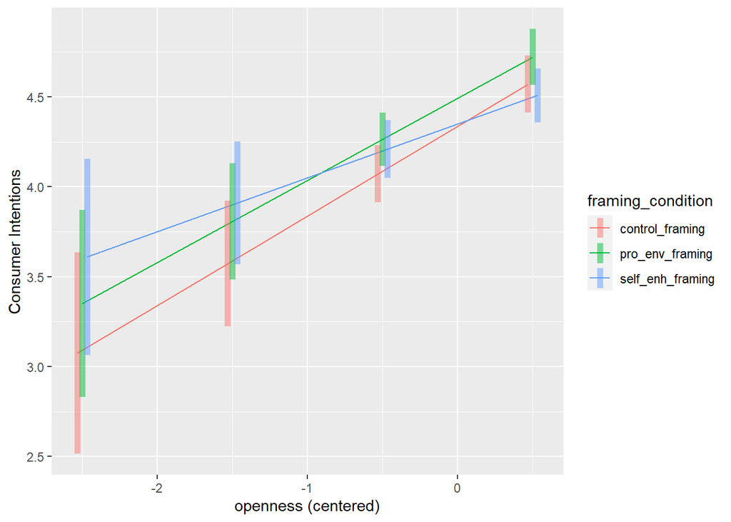

```r
# On a single graph
at_list <- list(openness_center = seq(-2.5, 1.4, by = 1))

emmip(mod_mice, framing_condition ~ openness_center, at = at_list, CIs = TRUE, xlab = "openness (centered)", ylab = "Consumer Intentions")
```

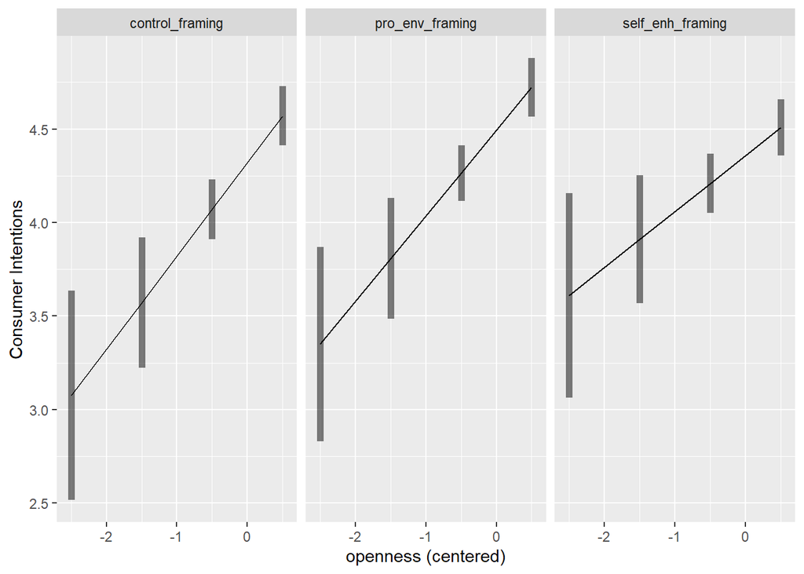

```r
# Separate graph for each norm
emmip(mod_mice, ~ openness_center | framing_condition, at = at_list, CIs = TRUE, xlab = "openness (centered)", ylab = "Consumer Intentions")
```

Is the slope of the relationship between openness & consumer intentions stronger in any one of the framing conditions compared to the others?

```r
emtrends(mod_mice, pairwise~framing_condition, var = "openness_center", adjust = "none")
```

```
## $emtrends
##  framing_condition openness_center.trend    SE  df lower.CL upper.CL
##  control_framing                   0.499 0.111 948   0.2800    0.717
##  pro_env_framing                   0.457 0.105 948   0.2522    0.662
##  self_enh_framing                  0.299 0.107 948   0.0886    0.510
##
## Results are averaged over the levels of: norm_condition, Gender
## Confidence level used: 0.95
##
## $contrasts
##  contrast                           estimate    SE  df t.ratio p.value
##  control_framing - pro_env_framing    0.0414 0.152 948   0.272  0.7853
##  control_framing - self_enh_framing   0.1992 0.154 948   1.295  0.1956
##  pro_env_framing - self_enh_framing   0.1578 0.149 948   1.057  0.2907
##
## Results are averaged over the levels of: norm_condition, Gender
```

Third, interaction between openness, framing, & norm condition:

```r
emtrends(mod_mice, ~norm_condition | framing_condition, var = "openness_center", adjust = "none")
```

```
## framing_condition = control_framing:
##  norm_condition   openness_center.trend    SE  df  lower.CL upper.CL
##  control_norm                    -0.144 0.222 948 -0.579929    0.291
##  descriptive_norm                 0.273 0.261 948 -0.239673    0.785
##  convention_norm                  0.655 0.244 948  0.175963    1.134
##  social_norm                      1.057 0.243 948  0.580579    1.533
##  moral_norm                       0.653 0.268 948  0.127336    1.179
##
## framing_condition = pro_env_framing:
##  norm_condition   openness_center.trend    SE  df  lower.CL upper.CL
##  control_norm                     0.512 0.260 948  0.000535    1.023
##  descriptive_norm                 0.455 0.229 948  0.005648    0.904
##  convention_norm                  0.436 0.209 948  0.026536    0.846
##  social_norm                      0.358 0.259 948 -0.149311    0.866
##  moral_norm                       0.525 0.201 948  0.130509    0.920
##
## framing_condition = self_enh_framing:
##  norm_condition   openness_center.trend    SE  df  lower.CL upper.CL
##  control_norm                     0.683 0.216 948  0.259591    1.107
##  descriptive_norm                -0.103 0.209 948 -0.512476    0.307
##  convention_norm                  0.219 0.247 948 -0.266207    0.705
##  social_norm                      0.221 0.260 948 -0.289619    0.731
##  moral_norm                       0.477 0.263 948 -0.039474    0.993
##
## Results are averaged over the levels of: Gender
## Confidence level used: 0.95
```

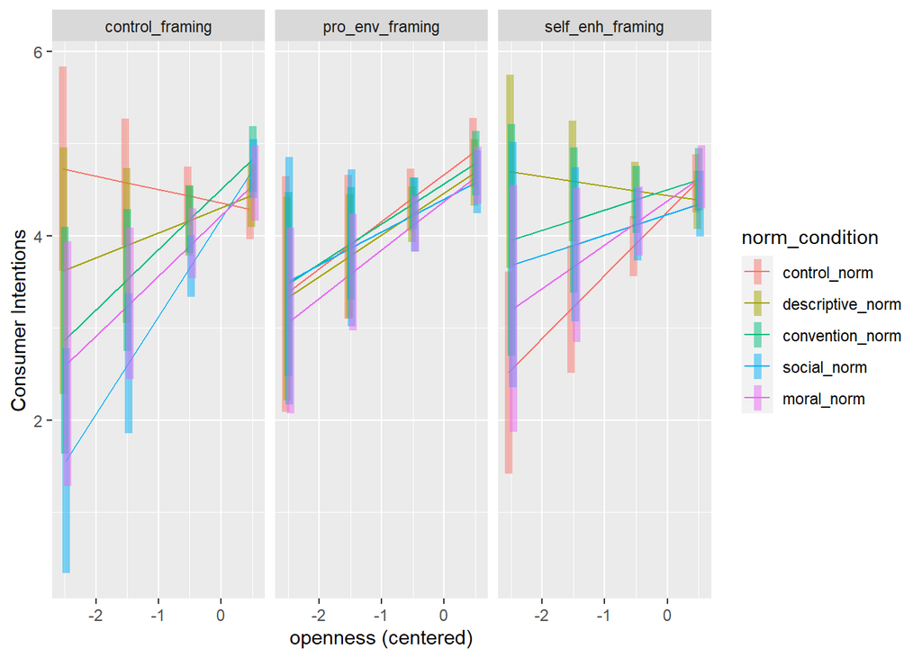

```r
# Separate graph for each framing condition
at_list <- list(openness_center = seq(-2.5, 1.4, by = 1))

emmip(mod_mice, norm_condition ~ openness_center | framing_condition, at = at_list, CIs = TRUE, xlab = "openness (centered)", ylab = "Consumer Intentions")
```

### Conscientiousness

First, relationship between conscientiousness & consumer intentions for each norm condition:

```r
emtrends(mod_mice, ~norm_condition, var = "conscientiousness_center", adjust = "none")
```

```
##  norm_condition   conscientiousness_center.trend    SE  df lower.CL upper.CL
##  control_norm                            -0.1862 0.144 948   -0.468   0.0957
##  descriptive_norm                         0.0384 0.146 948   -0.248   0.3252
##  convention_norm                          0.1560 0.132 948   -0.102   0.4142
##  social_norm                             -0.4766 0.134 948   -0.739  -0.2144
##  moral_norm                               0.1259 0.133 948   -0.134   0.3863
##
## Results are averaged over the levels of: framing_condition, Gender
## Confidence level used: 0.95
```

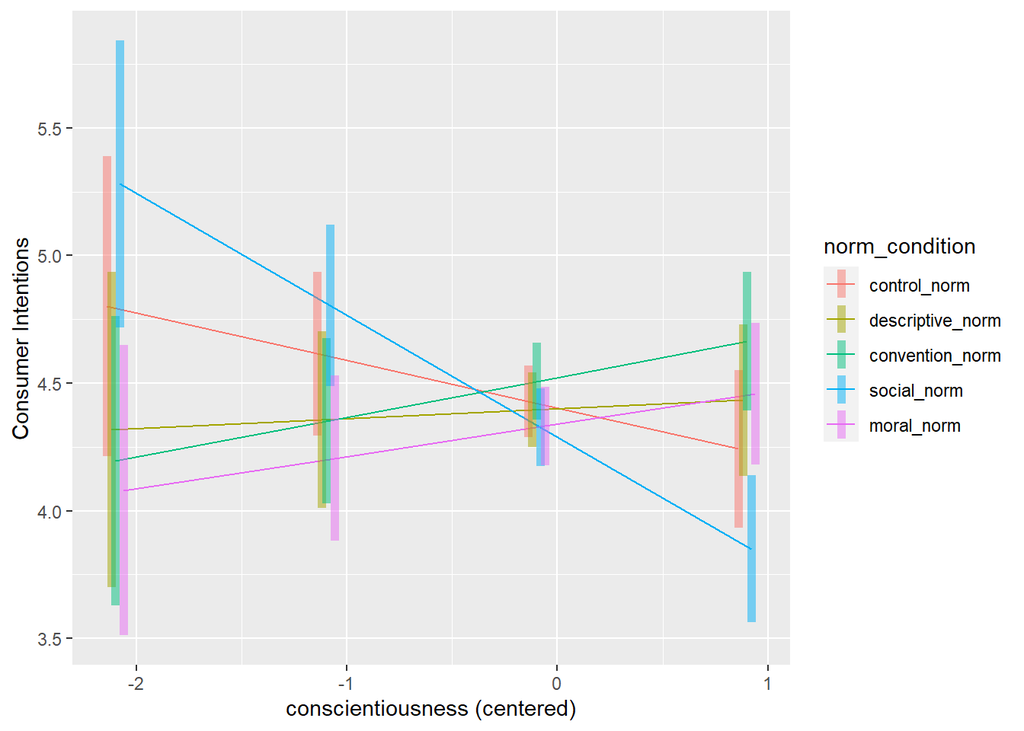

```r
# On a single graph
at_list <- list(conscientiousness_center = seq(-2.1, 1.7, by = 1))

emmip(mod_mice, norm_condition ~ conscientiousness_center, at = at_list, CIs = TRUE, xlab = "conscientiousness (centered)", ylab = "Consumer Intentions")
```

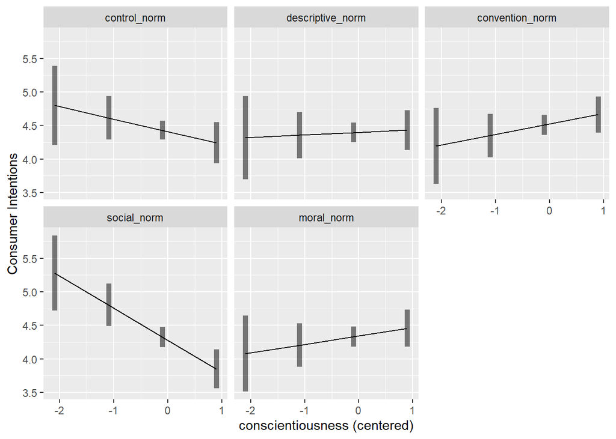

```r
# Separate graph for each norm
emmip(mod_mice, ~ conscientiousness_center | norm_condition, at = at_list, CIs = TRUE, xlab = "conscientiousness (centered)", ylab = "Consumer Intentions")
```

Is the slope of the relationship between conscientiousness & consumer intentions stronger in any one of the norm conditions compared to the others?

```r
emtrends(mod_mice, pairwise~norm_condition, var = "conscientiousness_center", adjust = "none")
```

```
## $emtrends
##  norm_condition   conscientiousness_center.trend    SE  df lower.CL upper.CL
##  control_norm                            -0.1862 0.144 948   -0.468   0.0957
##  descriptive_norm                         0.0384 0.146 948   -0.248   0.3252
##  convention_norm                          0.1560 0.132 948   -0.102   0.4142
##  social_norm                             -0.4766 0.134 948   -0.739  -0.2144
##  moral_norm                               0.1259 0.133 948   -0.134   0.3863
##
## Results are averaged over the levels of: framing_condition, Gender
## Confidence level used: 0.95
##
## $contrasts
##  contrast                           estimate    SE  df t.ratio p.value
##  control_norm - descriptive_norm     -0.2246 0.205 948  -1.098  0.2723
##  control_norm - convention_norm      -0.3422 0.194 948  -1.763  0.0782
##  control_norm - social_norm           0.2903 0.195 948   1.491  0.1362
##  control_norm - moral_norm           -0.3121 0.194 948  -1.608  0.1081
##  descriptive_norm - convention_norm  -0.1176 0.196 948  -0.601  0.5482
##  descriptive_norm - social_norm       0.5150 0.197 948   2.611  0.0092
##  descriptive_norm - moral_norm       -0.0875 0.197 948  -0.443  0.6576
##  convention_norm - social_norm        0.6326 0.186 948   3.405  0.0007
##  convention_norm - moral_norm         0.0301 0.186 948   0.162  0.8715
##  social_norm - moral_norm            -0.6025 0.186 948  -3.235  0.0013
##
## Results are averaged over the levels of: framing_condition, Gender
```

Second, relationship between conscientiousness & consumer intentions for each framing condition:

```r
emtrends(mod_mice, ~framing_condition, var = "conscientiousness_center", adjust = "none")
```

```
##  framing_condition conscientiousness_center.trend    SE  df lower.CL upper.CL
##  control_framing                          -0.2962 0.109 948   -0.511  -0.0816
##  pro_env_framing                           0.0497 0.101 948   -0.149   0.2482
##  self_enh_framing                          0.0411 0.110 948   -0.175   0.2569
##
## Results are averaged over the levels of: norm_condition, Gender
## Confidence level used: 0.95
```

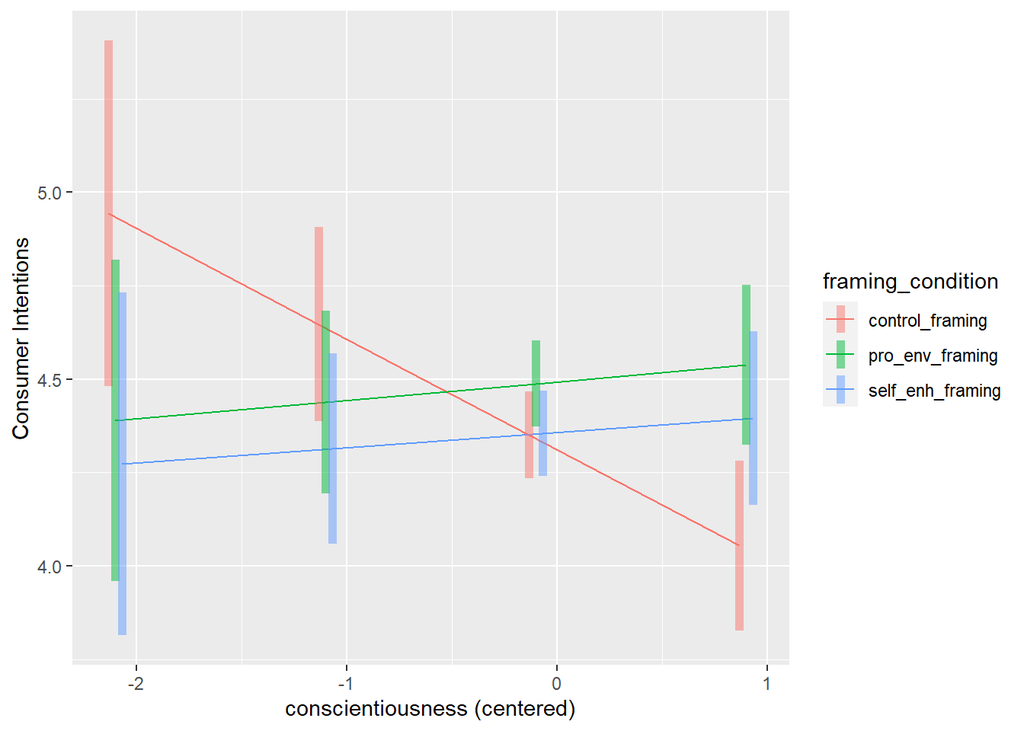

```r
# On a single graph
at_list <- list(conscientiousness_center = seq(-2.1, 1.7, by = 1))

emmip(mod_mice, framing_condition ~ conscientiousness_center, at = at_list, CIs = TRUE, xlab = "conscientiousness (centered)", ylab = "Consumer Intentions")
```

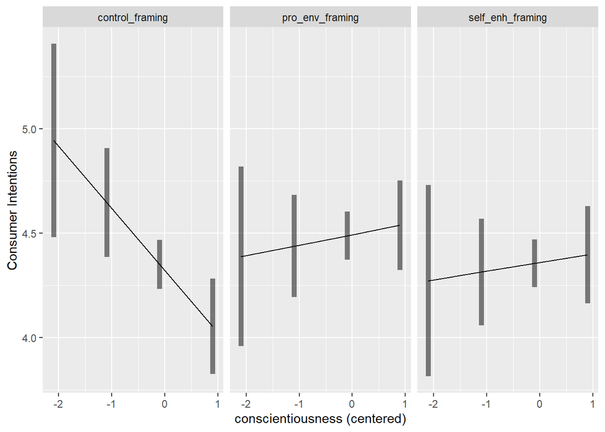

```r
# Separate graph for each norm
emmip(mod_mice, ~ conscientiousness_center | framing_condition, at = at_list, CIs = TRUE, xlab = "conscientiousness (centered)", ylab = "Consumer Intentions")
```

Is the slope of the relationship between conscientiousness & consumer intentions stronger in any one of the framing conditions compared to the others?

```r
emtrends(mod_mice, pairwise~framing_condition, var = "conscientiousness_center", adjust = "none")
```

```
## $emtrends
##  framing_condition conscientiousness_center.trend    SE  df lower.CL upper.CL
##  control_framing                          -0.2962 0.109 948   -0.511  -0.0816
##  pro_env_framing                           0.0497 0.101 948   -0.149   0.2482
##  self_enh_framing                          0.0411 0.110 948   -0.175   0.2569
##
## Results are averaged over the levels of: norm_condition, Gender
## Confidence level used: 0.95
##
## $contrasts
##  contrast                           estimate    SE  df t.ratio p.value
##  control_framing - pro_env_framing  -0.34594 0.148 948  -2.345  0.0192
##  control_framing - self_enh_framing -0.33736 0.154 948  -2.193  0.0286
##  pro_env_framing - self_enh_framing  0.00858 0.148 948   0.058  0.9538
##
## Results are averaged over the levels of: norm_condition, Gender
```

Third, interaction between conscientiousness, framing, & norm condition:

```r
emtrends(mod_mice, ~norm_condition | framing_condition, var = "conscientiousness_center", adjust = "none")
```

```
## framing_condition = control_framing:
##  norm_condition   conscientiousness_center.trend    SE  df lower.CL upper.CL
##  control_norm                           -0.62959 0.281 948 -1.18202  -0.0772
##  descriptive_norm                        0.02867 0.261 948 -0.48340   0.5407
##  convention_norm                        -0.07293 0.238 948 -0.53911   0.3933
##  social_norm                            -0.56012 0.194 948 -0.94020  -0.1800
##  moral_norm                             -0.24728 0.232 948 -0.70345   0.2089
##
## framing_condition = pro_env_framing:
##  norm_condition   conscientiousness_center.trend    SE  df lower.CL upper.CL
##  control_norm                           -0.04668 0.220 948 -0.47869   0.3853
##  descriptive_norm                        0.09381 0.245 948 -0.38628   0.5739
##  convention_norm                         0.45162 0.226 948  0.00902   0.8942
##  social_norm                            -0.21742 0.218 948 -0.64531   0.2105
##  moral_norm                             -0.03289 0.213 948 -0.45113   0.3854
##
## framing_condition = self_enh_framing:
##  norm_condition   conscientiousness_center.trend    SE  df lower.CL upper.CL
##  control_norm                            0.11764 0.239 948 -0.35226   0.5875
##  descriptive_norm                       -0.00719 0.255 948 -0.50844   0.4941
##  convention_norm                         0.08933 0.217 948 -0.33640   0.5150
##  social_norm                            -0.65213 0.269 948 -1.18093  -0.1233
##  moral_norm                              0.65790 0.240 948  0.18650   1.1293
##
## Results are averaged over the levels of: Gender
## Confidence level used: 0.95
```

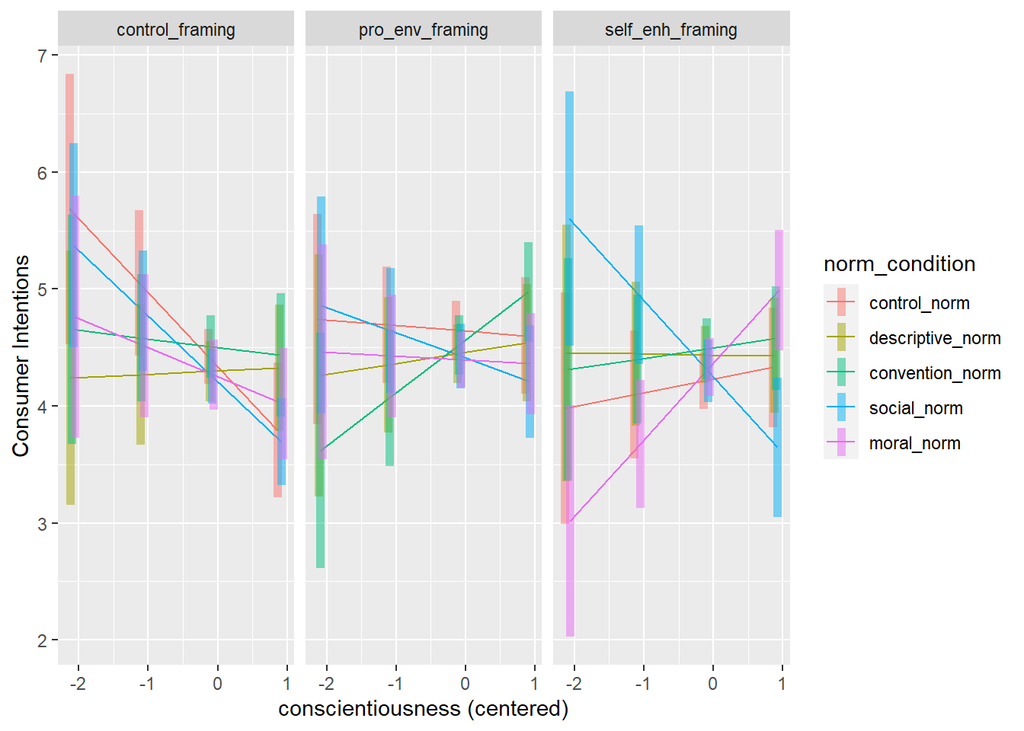

```r
# Separate graph for each framing condition
at_list <- list(conscientiousness_center = seq(-2.1, 1.7, by = 1))

emmip(mod_mice, norm_condition ~ conscientiousness_center | framing_condition, at = at_list, CIs = TRUE, xlab = "conscientiousness (centered)", ylab = "Consumer Intentions")
```